# Alternative_K_method

Liam

2022-08-23

We will use mean square error to estimate K using different traditional methods.

# Prepare workspace

```r
library(ggplot2)
library(FSA)
library(SHIM)
library(hyenaR)
library(dplyr)
```

Define important variables: r - Database path

- Age at which recruits are considered (we use 6 months to match data in simulation)
- Time step (we use 6 months. 1 month has very high temporal auto-correlation)

```r
db.path     <- "~/data/hyena_data/Fisidata_2023_03_07.sqlite"
recruit_age <- 6
time_step   <- 6
```

- Define the scale over which we will plot our estimated demographic mods

```r
plot_range <- seq(0, 1000, 10)
```

```r
load_package_database.full(db.path = db.path)
```

```
## The last observation in the loaded database is 94 days old!
```

```
## Perhaps you should update it!
##  For this:
##  1. download the new data (see, ?download_package_csv)
##  2. rebuild the database (see ?build_package_database.full)
```

# Extract data on population size and recruits.

```r
pop_size <- data.frame(from = seq(as.Date("1996-07-01"), as.Date("2022-01-01"), by = paste(time_step, "months"))) %>%
  mutate(to = lead(from)) %>%
  filter(!is.na(to)) %>%
  mutate(pop_size = fetch_pop_number(main.clans = TRUE, from = from, to = to)) %>%
  rowwise() %>%
  mutate(all_cubs = list(find_pop_id.anysex.cub(from = from, to = to, lifestage.overlap = "start"))) %>%
  mutate(number_recruit = sum(fetch_id_is.alive(ID = all_cubs, at = fetch_id_date.at.age(ID = all_cubs, age = recruit_age, unit = "month")))) %>%
  ungroup() %>%
  #We also want Nt+1 and log growth values
  mutate(Nt1 = lead(pop_size),
         lngrowth = log(Nt1) - log(pop_size))
```

```
## Caching life history table (only happens the first time the function is being called, for speed up in future calls. Be patient)...
```

Truncated data where removing last timestep where population at t+1 is unknown.

```r
pop_size_trunc <- pop_size %>%
  filter(!is.na(lngrowth))
```

# Write functions

## Demographic fns

These functions are all used to estimate K when given N.

```r
sheph_mod <- FSA::srFuns(type = "Shepherd")

ricker_exp_mod <- function(N, Rmax, K){

  K <- 1/K

  output <- Rmax*(1-N/K)

  return(output)

}

ricker_hyp_mod <- function(N, Rmax, K){

  K <- 1/K

  output <- Rmax - log(1 + (exp(Rmax) - 1)*N/K)

  return(output)

}

bh_exp_mod <- function(N, Rmax, K){

  K <- 1/K

  output <- N*exp(Rmax*(1 - N/K))

  return(output)

}

bh_hyp_mod <- function(N, Rmax, K){

  K <- 1/K

  numerator   <- exp(Rmax)*N
  denominator <- 1 + (exp(Rmax) - 1)*N/K

  output <- numerator/denominator

  return(output)

}

#Wrapper to fit all BH and Ricker mods
aggregate_mod <- function(N, Rmax, K, type){

  mod <- switch(type,
                Ricker_exp = ricker_exp_mod,
                Ricker_hyp = ricker_hyp_mod,
                BH_exp = bh_exp_mod,
                BH_hyp = bh_hyp_mod)

  mod(N = N, Rmax = Rmax, K = K)

}
```

## Create dummy data that will be used to test optimizers on known outcomes.

```r
#Test it out using nlm and dummy data
pop_size_test <- data.frame(pop_size = floor(runif(n = 1000, max = 1000))) %>%
  mutate(number_recruit = sheph_mod(S = pop_size, a = 0.05, b = 1/700, c = 2) + rnorm(n = n(), sd = 3),
         lngrowth = ricker_exp_mod(N = pop_size, Rmax = 5, K = 1/700) + rnorm(n = n(), sd = 0.5),
         Nt1 = as.integer(bh_exp_mod(N = pop_size, Rmax = 0.5, K = 1/700) + rnorm(n = n(), sd = 1))) %>%
  #If it dropped below 0 just fix at 0
  mutate(number_recruit = case_when(number_recruit < 0 ~ 0,
                                    TRUE ~ number_recruit)) %>%
  arrange(pop_size)
```

## Generic optimizer

```r
generic_optim <- function(input, data, type = c("Ricker_exp", "Ricker_hyp",
                                                "BH_exp", "BH_hyp",
                                                "Shepherd")){

  y_obsv <- switch(type,
                   Ricker_exp = data$lngrowth,
                   Ricker_hyp = data$lngrowth,
                   BH_exp = data$Nt1,
                   BH_hyp = data$Nt1,
                   Shepherd = data$number_recruit)

  if (type == "Shepherd") {
    y_hat  <- mod(S = data$pop_size, a = input[1], b = input[2], c = input[3])
  } else {
    y_hat  <- aggregate_mod(N = data$pop_size, Rmax = input[1], K = input[2], type = type)
  }

  sq_diff <- (y_obsv - y_hat)^2

  sum(sq_diff)/nrow(data)

}
```

## Iterate over multiple starting values

Function to return MSE and K from optimizer with given inputs

```r
generic_optim_output <- function(input, data, type, optim_fn, ...){

  output <- optim_fn(input,
                     generic_optim,
                     data = data, type = type,
                     ...)

  input_df <- as.data.frame(matrix(input, ncol = 2))

  if (inherits(output, "nloptr")) {
    return(tibble(MSE = output$objective,
                  optRmax = output$solution[1],
                  optK = 1/output$solution[2]) %>% bind_cols(input_df))
  } else if (inherits(output, "minqa")) {
    return(tibble(MSE = output$fval,
                  optRmax = output$par[1],
                  optK = 1/output$par[2]) %>% bind_cols(input_df))
  } else {
    return(tibble(MSE = ifelse("value" %in% names(output), output$value, output$objective),
                  optRmax = output$par[1],
                  optK = 1/output$par[2]) %>% bind_cols(input_df))
  }

}
```

```r
iterate_optim <- function(Rmax, K, data, type, optim_fn, ...){

  if (all(sapply(list(Rmax, K), FUN = length) > 1)) {
    stop("One of K or Rmax should be fixed")
  }

  if (length(Rmax) > 1) {
    output <- purrr::map_df(.x = Rmax,
                            .f = function(Rmax, K){

                              generic_optim_output(input = c(Rmax, K),
                                                   data = data,
                                                   type = type,
                                                   optim_fn = optim_fn, ...)

                            }, K = K)
  } else {
    output <- purrr::map_df(.x = K,
                            .f = function(Rmax, K){

                              generic_optim_output(input = c(Rmax, K),
                                                   data = data,
                                                   type = type,
                                                   optim_fn = optim_fn, ...)

                            }, Rmax = Rmax)
  }

  return(output)

}
```

```r
plot_iterated_optim <- function(input, k = 20){
  ggplot(data = input) +
    geom_point(aes(x = optK, y = MSE)) +
    geom_smooth(aes(x = optK, y = MSE),
                method = "gam",
                formula = y ~ s(x, k = k), se = FALSE,
                linewidth = 0.25)
}
```

Test example

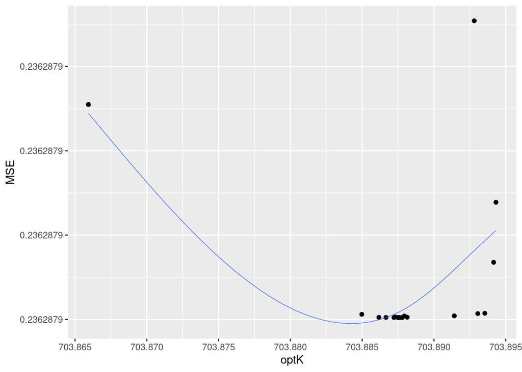

```r
plot_output <- iterate_optim(Rmax = seq(0, 2, 0.1), K = 1/200, data = pop_size_test, type = "Ricker_exp",
                             optim_fn = nloptr::nloptr,
                             lb = c(0, 1/2000),
                             ub = c(Inf, 1/100),
                             opts = list(algorithm = "NLOPT_LN_BOBYQA",
                                         #By making maxeval -1 we don't put a limit on number of evaluations
                                         maxeval = -1,
                                         #Minimum printing
                                         print_level = 0,
                                         #Set seed
                                         ranseed = 123))

plot_iterated_optim(plot_output, k = 10)
```

Function that iterates across both Rmax and K for every Ricker and BH function. We fix the unused variable at its mean.

```r
iterate_optim_all <- function(Rmax, K, data, type, optim_fn, ...){

  all_mods <- purrr::map_df(.x = c("Ricker_exp", "Ricker_hyp",
                                   "BH_exp", "BH_hyp"),
                            .f = function(type){

                              Rmaxoutput <- purrr::map_df(.x = Rmax,
                                                          .f = function(Rmax, K, type){

                                                            generic_optim_output(input = c(Rmax, K),
                                                                                 data = data,
                                                                                 type = type,
                                                                                 optim_fn = optim_fn, ...)

                                                          }, K = mean(K), type = type)

                              Koutput <- purrr::map_df(.x = K,
                                                       .f = function(Rmax, K, type){

                                                         generic_optim_output(input = c(Rmax, K),
                                                                              data = data,
                                                                              type = type,
                                                                              optim_fn = optim_fn, ...)

                                                       }, Rmax = mean(Rmax), type = type)

                              output <- Rmaxoutput %>%
                                bind_rows(Koutput) %>%
                                mutate(type = type)

                            })

  return(all_mods)

}
```

```r
plot_iterated_optim_all <- function(input, k = 20, scales = "free"){
  ggplot(data = input) +
    geom_point(aes(x = optK, y = MSE)) +
    geom_smooth(aes(x = optK, y = MSE),
                method = "gam",
                formula = y ~ s(x, k = k), se = FALSE,
                linewidth = 0.25) +
    facet_wrap(facets = ~type, scales = scales)
}
```

Test

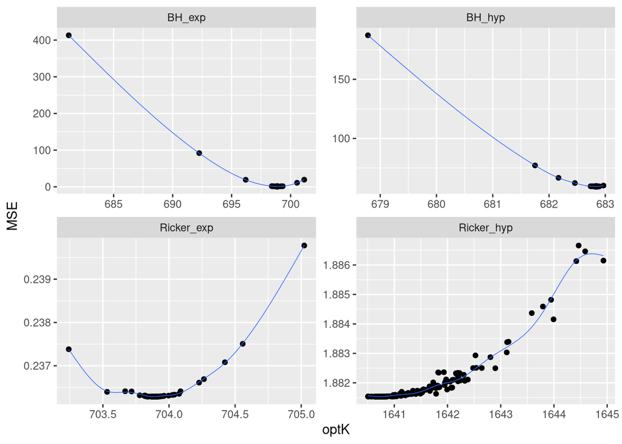

```r
test_optim_all <- iterate_optim_all(Rmax = seq(0, 1, 1e-3), K = 1/seq(100, 1000, 100), data = pop_size_test,
                                    optim_fn = nloptr::nloptr,
                                    lb = c(0, 1/2000),
                                    ub = c(Inf, 1/100),
                                    opts = list(algorithm = "NLOPT_LN_BOBYQA",
                                                #By making maxeval -1 we don't put a limit on number of evaluations
                                                maxeval = -1,
                                                #Minimum printing
                                                print_level = 0,
                                                #Set seed
                                                ranseed = 123))

#In this case, Ricker hyperbolic seems to fail
plot_iterated_optim_all(test_optim_all, k = 10)
```

# Run different optimizers

## nloptr bobyqa

First, test it works on data where we know the values. Try this for Ricker and Beverton-Holt. Just use exponential form of BH and Ricker, should be comparable.

```r
## TEST IT WORKS AS EXPECTED
#Looks ok
(test <- nloptr::nloptr(x0 = c(0, 1/200),
                        eval_f = generic_optim,
                        lb = c(0, 1/2000),
                        ub = c(2, 1/100),
                        data = pop_size_test, type = "Ricker_exp",
                        opts = list(algorithm = "NLOPT_LN_BOBYQA",
                                    #By making maxeval -1 we don't put a limit on number of evaluations
                                    maxeval = -1,
                                    #Minimum printing
                                    print_level = 0,
                                    #Set seed
                                    ranseed = 123)))
```

```
##
## Call:
## nloptr::nloptr(x0 = c(0, 1/200), eval_f = generic_optim, lb = c(0,
##     1/2000), ub = c(2, 1/100), opts = list(algorithm = "NLOPT_LN_BOBYQA",
##     maxeval = -1, print_level = 0, ranseed = 123), data = pop_size_test,
##     type = "Ricker_exp")
##
##
## Minimization using NLopt version 2.7.1
##
## NLopt solver status: 4 ( NLOPT_XTOL_REACHED: Optimization stopped because
## xtol_rel or xtol_abs (above) was reached. )
##
## Number of Iterations....: 32
## Termination conditions:  maxeval: -1
## Number of inequality constraints:  0
## Number of equality constraints:    0
## Optimal value of objective function:  2.51557903525373
## Optimal value of controls: 2 0.001276848
```

```r
1/test$solution[2]
```

```
## [1] 783.1785
```

```r
## TEST IT WORKS AS EXPECTED
#Looks ok
(test <- nloptr::nloptr(x0 = c(0, 1/200),
                        eval_f = generic_optim,
                        lb = c(0, 1/2000),
                        ub = c(2, 1/100),
                        data = pop_size_test, type = "BH_exp",
                        opts = list(algorithm = "NLOPT_LN_BOBYQA",
                                    #By making maxeval -1 we don't put a limit on number of evaluations
                                    maxeval = -1,
                                    #Minimum printing
                                    print_level = 0,
                                    #Set seed
                                    ranseed = 123)))
```

```
##
## Call:
## nloptr::nloptr(x0 = c(0, 1/200), eval_f = generic_optim, lb = c(0,
##     1/2000), ub = c(2, 1/100), opts = list(algorithm = "NLOPT_LN_BOBYQA",
##     maxeval = -1, print_level = 0, ranseed = 123), data = pop_size_test,
##     type = "BH_exp")
##
##
## Minimization using NLopt version 2.7.1
##
## NLopt solver status: 4 ( NLOPT_XTOL_REACHED: Optimization stopped because
## xtol_rel or xtol_abs (above) was reached. )
##
## Number of Iterations....: 71
## Termination conditions:  maxeval: -1
## Number of inequality constraints:  0
## Number of equality constraints:    0
## Optimal value of objective function:  1.13215198847181
## Optimal value of controls: 0.4985085 0.001430883
```

```r
1/test$solution[2]
```

```
## [1] 698.8692
```

Now use to optimize real data.

Ricker exponential

```r
(nloptr_bobyqa_Rickerexp <- nloptr::nloptr(x0 = c(1, 1/500),
                                           eval_f = generic_optim,
                                           lb = c(0, 1/2000),
                                           ub = c(Inf, 1/100),
                                           data = pop_size_trunc, type = "Ricker_exp",
                                           opts = list(algorithm = "NLOPT_LN_BOBYQA",
                                                       #By making maxeval -1 we don't put a limit on number of evaluations
                                                       maxeval = -1,
                                                       #Minimum printing
                                                       print_level = 0,
                                                       #Set seed
                                                       ranseed = 123)))
```

```
##
## Call:
## nloptr::nloptr(x0 = c(1, 1/500), eval_f = generic_optim, lb = c(0,
##     1/2000), ub = c(Inf, 1/100), opts = list(algorithm = "NLOPT_LN_BOBYQA",
##     maxeval = -1, print_level = 0, ranseed = 123), data = pop_size_trunc,
##     type = "Ricker_exp")
##
##
## Minimization using NLopt version 2.7.1
##
## NLopt solver status: 4 ( NLOPT_XTOL_REACHED: Optimization stopped because
## xtol_rel or xtol_abs (above) was reached. )
##
## Number of Iterations....: 39
## Termination conditions:  maxeval: -1
## Number of inequality constraints:  0
## Number of equality constraints:    0
## Optimal value of objective function:  0.00380075756423322
## Optimal value of controls: 0.09289064 0.00191143
```

```r
paste("K =", 1/nloptr_bobyqa_Rickerexp$solution[2])
```

```
## [1] "K = 523.16863687974"
```

Ricker hyperbolic

```r
(nloptr_bobyqa_Rickerhyp <- nloptr::nloptr(x0 = c(1, 1/500),
                                           eval_f = generic_optim,
                                           lb = c(0, 1/2000),
                                           ub = c(Inf, 1/100),
                                           data = pop_size_trunc, type = "Ricker_hyp",
                                           opts = list(algorithm = "NLOPT_LN_BOBYQA",
                                                       #By making maxeval -1 we don't put a limit on number of evaluations
                                                       maxeval = -1,
                                                       #Minimum printing
                                                       print_level = 0,
                                                       #Set seed
                                                       ranseed = 123)))
```

```
##
## Call:
## nloptr::nloptr(x0 = c(1, 1/500), eval_f = generic_optim, lb = c(0,
##     1/2000), ub = c(Inf, 1/100), opts = list(algorithm = "NLOPT_LN_BOBYQA",
##     maxeval = -1, print_level = 0, ranseed = 123), data = pop_size_trunc,
##     type = "Ricker_hyp")
##
##
## Minimization using NLopt version 2.7.1
##
## NLopt solver status: 4 ( NLOPT_XTOL_REACHED: Optimization stopped because
## xtol_rel or xtol_abs (above) was reached. )
##
## Number of Iterations....: 59
## Termination conditions:  maxeval: -1
## Number of inequality constraints:  0
## Number of equality constraints:    0
## Optimal value of objective function:  0.00380319434262695
## Optimal value of controls: 0.09526209 0.001912425
```

```r
paste("K =", 1/nloptr_bobyqa_Rickerhyp$solution[2])
```

```
## [1] "K = 522.896279659739"
```

Beverton-Holt exponential

```r
(nloptr_bobyqa_BHexp <- nloptr::nloptr(x0 = c(1, 1/500),
                                       eval_f = generic_optim,
                                       lb = c(0, 1/2000),
                                       ub = c(Inf, 1/100),
                                       data = pop_size_trunc, type = "BH_exp",
                                       opts = list(algorithm = "NLOPT_LN_BOBYQA",
                                                   #By making maxeval -1 we don't put a limit on number of evaluations
                                                   maxeval = -1,
                                                   #Minimum printing
                                                   print_level = 0,
                                                   #Set seed
                                                   ranseed = 123)))
```

```
##
## Call:
## nloptr::nloptr(x0 = c(1, 1/500), eval_f = generic_optim, lb = c(0,
##     1/2000), ub = c(Inf, 1/100), opts = list(algorithm = "NLOPT_LN_BOBYQA",
##     maxeval = -1, print_level = 0, ranseed = 123), data = pop_size_trunc,
##     type = "BH_exp")
##
##
## Minimization using NLopt version 2.7.1
##
## NLopt solver status: 4 ( NLOPT_XTOL_REACHED: Optimization stopped because
## xtol_rel or xtol_abs (above) was reached. )
##
## Number of Iterations....: 36
## Termination conditions:  maxeval: -1
## Number of inequality constraints:  0
## Number of equality constraints:    0
## Optimal value of objective function:  880.277958821366
## Optimal value of controls: 0.1037128 0.001884009
```

```r
paste("K =", 1/nloptr_bobyqa_BHexp$solution[2])
```

```
## [1] "K = 530.782923384644"
```

Beverton-Holt hyperbolic

```r
(nloptr_bobyqa_BHhyp <- nloptr::nloptr(x0 = c(1, 1/500),
                                       eval_f = generic_optim,
                                       lb = c(0, 1/2000),
                                       ub = c(Inf, 1/100),
                                       data = pop_size_trunc, type = "BH_hyp",
                                       opts = list(algorithm = "NLOPT_LN_BOBYQA",
                                                   #By making maxeval -1 we don't put a limit on number of evaluations
                                                   maxeval = -1,
                                                   #Minimum printing
                                                   print_level = 0,
                                                   #Set seed
                                                   ranseed = 123)))
```

```
##
## Call:
## nloptr::nloptr(x0 = c(1, 1/500), eval_f = generic_optim, lb = c(0,
##     1/2000), ub = c(Inf, 1/100), opts = list(algorithm = "NLOPT_LN_BOBYQA",
##     maxeval = -1, print_level = 0, ranseed = 123), data = pop_size_trunc,
##     type = "BH_hyp")
##
##
## Minimization using NLopt version 2.7.1
##
## NLopt solver status: 1 ( NLOPT_SUCCESS: Generic success return value. )
##
## Number of Iterations....: 55
## Termination conditions:  maxeval: -1
## Number of inequality constraints:  0
## Number of equality constraints:    0
## Optimal value of objective function:  880.82266677551
## Optimal value of controls: 0.1073138 0.001887133
```

```r
paste("K =", 1/nloptr_bobyqa_BHhyp$solution[2])
```

```
## [1] "K = 529.904496161914"
```

Test how sensititive this is to optimizers starting values.

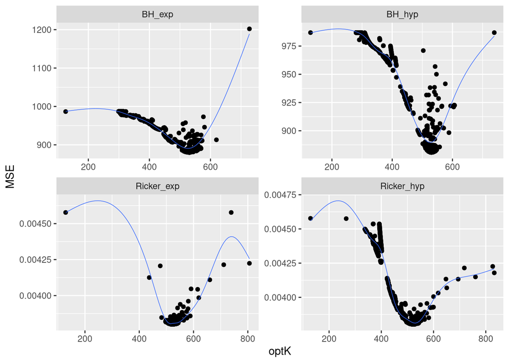

```r
plot_nloptr_bobyqa <- iterate_optim_all(Rmax = seq(0, 1, 1e-3), K = 1/seq(100, 1000, 100), data = pop_size_trunc,
                                        optim_fn = nloptr::nloptr,
                                        lb = c(0, 1/2000),
                                        ub = c(Inf, 1/100),
                                        opts = list(algorithm = "NLOPT_LN_BOBYQA",
                                                    #By making maxeval -1 we don't put a limit on number of evaluations
                                                    maxeval = -1,
                                                    #Found that setting xtol_abs helps to reduce sensitivity to starting vals
                                                    xtol_abs = c(1e-4, 0),
                                                    #Minimum printing
                                                    print_level = 0,
                                                    #Set seed
                                                    ranseed = 123))

plot_iterated_optim_all(plot_nloptr_bobyqa, k = 10)
```

Extract best starting parameters to achieve lowest MSE and fit predicted values.

```r
plot_nloptr_bobyqa_best <- plot_nloptr_bobyqa %>%
  group_by(type) %>%
  filter(MSE == min(MSE)) %>%
  rowwise() %>%
  mutate(y = list(aggregate_mod(N = plot_range, Rmax = optRmax, K = 1/optK, type = type)),
         x = list(plot_range),
         opt = "NLOPTR_BOBYQA") %>%
  ungroup()
```

## nloptr cobyla

```r
## TEST IT WORKS AS EXPECTED
#Looks ok
(test <- nloptr::nloptr(x0 = c(0, 1/200),
                        eval_f = generic_optim,
                        lb = c(0, 1/2000),
                        ub = c(2, 1/100),
                        data = pop_size_test, type = "Ricker_exp",
                        opts = list(algorithm = "NLOPT_LN_COBYLA",
                                    #By making maxeval -1 we don't put a limit on number of evaluations
                                    maxeval = -1,
                                    #Minimum printing
                                    print_level = 0,
                                    #Set seed
                                    ranseed = 123)))
```

```
##
## Call:
## nloptr::nloptr(x0 = c(0, 1/200), eval_f = generic_optim, lb = c(0,
##     1/2000), ub = c(2, 1/100), opts = list(algorithm = "NLOPT_LN_COBYLA",
##     maxeval = -1, print_level = 0, ranseed = 123), data = pop_size_test,
##     type = "Ricker_exp")
##
##
## Minimization using NLopt version 2.7.1
##
## NLopt solver status: 4 ( NLOPT_XTOL_REACHED: Optimization stopped because
## xtol_rel or xtol_abs (above) was reached. )
##
## Number of Iterations....: 60
## Termination conditions:  maxeval: -1
## Number of inequality constraints:  0
## Number of equality constraints:    0
## Optimal value of objective function:  2.51557917355736
## Optimal value of controls: 2 0.001276523
```

```r
1/test$solution[2]
```

```
## [1] 783.3781
```

```r
## TEST IT WORKS AS EXPECTED
(test <- nloptr::nloptr(x0 = c(0, 1/200),
                        eval_f = generic_optim,
                        lb = c(0, 1/2000),
                        ub = c(2, 1/100),
                        data = pop_size_test, type = "BH_exp",
                        opts = list(algorithm = "NLOPT_LN_COBYLA",
                                    #By making maxeval -1 we don't put a limit on number of evaluations
                                    maxeval = -1,
                                    #Minimum printing
                                    print_level = 0,
                                    #Set seed
                                    ranseed = 123)))
```

```
##
## Call:
## nloptr::nloptr(x0 = c(0, 1/200), eval_f = generic_optim, lb = c(0,
##     1/2000), ub = c(2, 1/100), opts = list(algorithm = "NLOPT_LN_COBYLA",
##     maxeval = -1, print_level = 0, ranseed = 123), data = pop_size_test,
##     type = "BH_exp")
##
##
## Minimization using NLopt version 2.7.1
##
## NLopt solver status: 4 ( NLOPT_XTOL_REACHED: Optimization stopped because
## xtol_rel or xtol_abs (above) was reached. )
##
## Number of Iterations....: 629
## Termination conditions:  maxeval: -1
## Number of inequality constraints:  0
## Number of equality constraints:    0
## Optimal value of objective function:  1.13563425367845
## Optimal value of controls: 0.4984531 0.001430603
```

```r
1/test$solution[2]
```

```
## [1] 699.0059
```

Now use to optimize real data.

Ricker exponential

```r
(nloptr_cobyla_Rickerexp <- nloptr::nloptr(x0 = c(1, 1/500),
                                           eval_f = generic_optim,
                                           lb = c(0, 1/2000),
                                           ub = c(Inf, 1/100),
                                           data = pop_size_trunc, type = "Ricker_exp",
                                           opts = list(algorithm = "NLOPT_LN_COBYLA",
                                                       #By making maxeval -1 we don't put a limit on number of evaluations
                                                       maxeval = -1,
                                                       #Minimum printing
                                                       print_level = 0,
                                                       #Set seed
                                                       ranseed = 123)))
```

```
##
## Call:
## nloptr::nloptr(x0 = c(1, 1/500), eval_f = generic_optim, lb = c(0,
##     1/2000), ub = c(Inf, 1/100), opts = list(algorithm = "NLOPT_LN_COBYLA",
##     maxeval = -1, print_level = 0, ranseed = 123), data = pop_size_trunc,
##     type = "Ricker_exp")
##
##
## Minimization using NLopt version 2.7.1
##
## NLopt solver status: 4 ( NLOPT_XTOL_REACHED: Optimization stopped because
## xtol_rel or xtol_abs (above) was reached. )
##
## Number of Iterations....: 107
## Termination conditions:  maxeval: -1
## Number of inequality constraints:  0
## Number of equality constraints:    0
## Optimal value of objective function:  0.00380075857429403
## Optimal value of controls: 0.09296793 0.001912138
```

```r
paste("K =", 1/nloptr_cobyla_Rickerexp$solution[2])
```

```
## [1] "K = 522.974735713426"
```

Ricker hyperbolic

```r
(nloptr_cobyla_Rickerhyp <- nloptr::nloptr(x0 = c(1, 1/500),
                                           eval_f = generic_optim,
                                           lb = c(0, 1/2000),
                                           ub = c(Inf, 1/100),
                                           data = pop_size_trunc, type = "Ricker_hyp",
                                           opts = list(algorithm = "NLOPT_LN_COBYLA",
                                                       #By making maxeval -1 we don't put a limit on number of evaluations
                                                       maxeval = -1,
                                                       #Minimum printing
                                                       print_level = 0,
                                                       #Set seed
                                                       ranseed = 123)))
```

```
##
## Call:
## nloptr::nloptr(x0 = c(1, 1/500), eval_f = generic_optim, lb = c(0,
##     1/2000), ub = c(Inf, 1/100), opts = list(algorithm = "NLOPT_LN_COBYLA",
##     maxeval = -1, print_level = 0, ranseed = 123), data = pop_size_trunc,
##     type = "Ricker_hyp")
##
##
## Minimization using NLopt version 2.7.1
##
## NLopt solver status: 4 ( NLOPT_XTOL_REACHED: Optimization stopped because
## xtol_rel or xtol_abs (above) was reached. )
##
## Number of Iterations....: 109
## Termination conditions:  maxeval: -1
## Number of inequality constraints:  0
## Number of equality constraints:    0
## Optimal value of objective function:  0.0038031952812699
## Optimal value of controls: 0.0953559 0.001913057
```

```r
paste("K =", 1/nloptr_cobyla_Rickerhyp$solution[2])
```

```
## [1] "K = 522.723501132636"
```

Beverton-Holt exponential

```r
(nloptr_cobyla_BHexp <- nloptr::nloptr(x0 = c(1, 1/500),
                                       eval_f = generic_optim,
                                       lb = c(0, 1/2000),
                                       ub = c(Inf, 1/100),
                                       data = pop_size_trunc, type = "BH_exp",
                                       opts = list(algorithm = "NLOPT_LN_COBYLA",
                                                   #By making maxeval -1 we don't put a limit on number of evaluations
                                                   maxeval = -1,
                                                   #Minimum printing
                                                   print_level = 0,
                                                   #Set seed
                                                   ranseed = 123)))
```

```
##
## Call:
## nloptr::nloptr(x0 = c(1, 1/500), eval_f = generic_optim, lb = c(0,
##     1/2000), ub = c(Inf, 1/100), opts = list(algorithm = "NLOPT_LN_COBYLA",
##     maxeval = -1, print_level = 0, ranseed = 123), data = pop_size_trunc,
##     type = "BH_exp")
##
##
## Minimization using NLopt version 2.7.1
##
## NLopt solver status: 4 ( NLOPT_XTOL_REACHED: Optimization stopped because
## xtol_rel or xtol_abs (above) was reached. )
##
## Number of Iterations....: 56
## Termination conditions:  maxeval: -1
## Number of inequality constraints:  0
## Number of equality constraints:    0
## Optimal value of objective function:  880.27808015121
## Optimal value of controls: 0.1038192 0.001884079
```

```r
paste("K =", 1/nloptr_cobyla_BHexp$solution[2])
```

```
## [1] "K = 530.763212421144"
```

Beverton-Holt hyperbolic

```r
(nloptr_cobyla_BHhyp <- nloptr::nloptr(x0 = c(1, 1/500),
                                       eval_f = generic_optim,
                                       lb = c(0, 1/2000),
                                       ub = c(Inf, 1/100),
                                       data = pop_size_trunc, type = "BH_hyp",
                                       opts = list(algorithm = "NLOPT_LN_COBYLA",
                                                   #By making maxeval -1 we don't put a limit on number of evaluations
                                                   maxeval = -1,
                                                   #Minimum printing
                                                   print_level = 0,
                                                   #Set seed
                                                   ranseed = 123)))
```

```
##
## Call:
## nloptr::nloptr(x0 = c(1, 1/500), eval_f = generic_optim, lb = c(0,
##     1/2000), ub = c(Inf, 1/100), opts = list(algorithm = "NLOPT_LN_COBYLA",
##     maxeval = -1, print_level = 0, ranseed = 123), data = pop_size_trunc,
##     type = "BH_hyp")
##
##
## Minimization using NLopt version 2.7.1
##
## NLopt solver status: 4 ( NLOPT_XTOL_REACHED: Optimization stopped because
## xtol_rel or xtol_abs (above) was reached. )
##
## Number of Iterations....: 53
## Termination conditions:  maxeval: -1
## Number of inequality constraints:  0
## Number of equality constraints:    0
## Optimal value of objective function:  880.8226473614
## Optimal value of controls: 0.1073512 0.0018869
```

```r
paste("K =", 1/nloptr_cobyla_BHhyp$solution[2])
```

```
## [1] "K = 529.969868087712"
```

Test how sensititive this is to optimizers starting values.

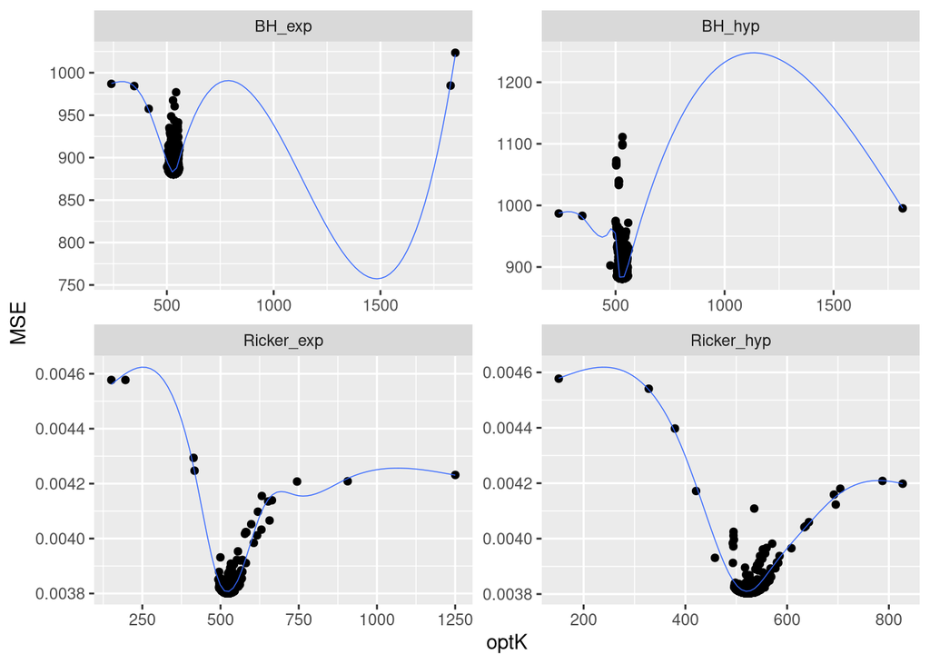

```r
plot_nloptr_cobyla <- iterate_optim_all(Rmax = seq(0, 1, 1e-3), K = 1/seq(100, 1000, 100), data = pop_size_trunc,
                                        optim_fn = nloptr::nloptr,
                                        lb = c(0, 1/2000),
                                        ub = c(Inf, 1/100),
                                        opts = list(algorithm = "NLOPT_LN_COBYLA",
                                                    #By making maxeval -1 we don't put a limit on number of evaluations
                                                    maxeval = -1,
                                                    #Found that setting xtol_abs helps to reduce sensitivity to starting vals
                                                    xtol_abs = c(5e-5, 0),
                                                    #Minimum printing
                                                    print_level = 0,
                                                    #Set seed
                                                    ranseed = 123))

plot_iterated_optim_all(plot_nloptr_cobyla, k = 10, scales = "free")
```

Extract best starting parameters to achieve lowest MSE

```r
plot_nloptr_cobyla_best <- plot_nloptr_cobyla %>%
  group_by(type) %>%
  filter(MSE == min(MSE)) %>%
  rowwise() %>%
  mutate(y = list(aggregate_mod(N = plot_range, Rmax = optRmax, K = 1/optK, type = type)),
         x = list(plot_range),
         opt = "NLOPTR_COBYLA") %>%
  ungroup()
```

## nloptr lbfgs

```r
## TEST IT WORKS AS EXPECTED
#Looks ok
(test <- nloptr::lbfgs(x0 = c(0, 1/200), f = generic_optim, lower = c(0, 1/2000), upper = c(2, 1/100),
                       data = pop_size_test, type = "Ricker_exp",
                       #Specifying xtol_rel seems to be necessary to achieve convergence
                       control = list(xtol_rel = 1e-7)))
```

```
## $par
## [1] 2.000000000 0.001276848
##
## $value
## [1] 2.515579
##
## $iter
## [1] 14
##
## $convergence
## [1] 1
##
## $message
## [1] "NLOPT_SUCCESS: Generic success return value."
```

```r
1/test$par[2]
```

```
## [1] 783.1785
```

```r
## TEST IT WORKS AS EXPECTED
#Looks ok
(test <- nloptr::lbfgs(x0 = c(0, 1/200), f = generic_optim, lower = c(0, 1/2000), upper = c(2, 1/100),
                       data = pop_size_test, type = "BH_exp",
                       control = list(xtol_rel = 1e-7)))
```

```
## $par
## [1] 0.498504181 0.001430889
##
## $value
## [1] 1.132154
##
## $iter
## [1] 23
##
## $convergence
## [1] 4
##
## $message
## [1] "NLOPT_XTOL_REACHED: Optimization stopped because xtol_rel or xtol_abs (above) was reached."
```

```r
1/test$par[2]
```

```
## [1] 698.8663
```

Now use to optimize real data.

Ricker exponential

```r
(nloptr_lbfgs_Rickerexp <- nloptr::lbfgs(x0 = c(0, 1/200), f = generic_optim, lower = c(0, 1/2000), upper = c(2, 1/100),
                                         data = pop_size_trunc, type = "Ricker_exp",
                                         control = list(xtol_rel = 1e-7)))
```

```
## $par
## [1] 0.000 0.005
##
## $value
## [1] 0.004577308
##
## $iter
## [1] 1
##
## $convergence
## [1] 1
##
## $message
## [1] "NLOPT_SUCCESS: Generic success return value."
```

```r
paste("K =", 1/nloptr_lbfgs_Rickerexp$par[2])
```

```
## [1] "K = 200"
```

Ricker hyperbolic

```r
(nloptr_lbfgs_Rickerhyp <- nloptr::lbfgs(x0 = c(0, 1/200), f = generic_optim, lower = c(0, 1/2000), upper = c(2, 1/100),
                                         data = pop_size_trunc, type = "Ricker_hyp",
                                         control = list(xtol_rel = 1e-7)))
```

```
## $par
## [1] 0.000 0.005
##
## $value
## [1] 0.004577308
##
## $iter
## [1] 1
##
## $convergence
## [1] 1
##
## $message
## [1] "NLOPT_SUCCESS: Generic success return value."
```

```r
paste("K =", 1/nloptr_lbfgs_Rickerhyp$par[2])
```

```
## [1] "K = 200"
```

Beverton-Holt exponential

```r
(nloptr_lbfgs_BHexp <- nloptr::lbfgs(x0 = c(0, 1/200), f = generic_optim, lower = c(0, 1/2000), upper = c(2, 1/100),
                                     data = pop_size_trunc, type = "BH_exp",
                                     control = list(xtol_rel = 1e-7)))
```

```
## $par
## [1] 0.103711182 0.001883991
##
## $value
## [1] 880.278
##
## $iter
## [1] 29
##
## $convergence
## [1] 3
##
## $message
## [1] "NLOPT_FTOL_REACHED: Optimization stopped because ftol_rel or ftol_abs (above) was reached."
```

```r
paste("K =", 1/nloptr_lbfgs_BHexp$par[2])
```

```
## [1] "K = 530.788076053072"
```

Beverton-Holt hyperbolic

```r
(nloptr_lbfgs_BH_hyp <- nloptr::lbfgs(x0 = c(0, 1/200), f = generic_optim, lower = c(0, 1/2000), upper = c(2, 1/100),
                                      data = pop_size_trunc, type = "BH_hyp",
                                      control = list(xtol_rel = 1e-7)))
```

```
## $par
## [1] 0.107290341 0.001886836
##
## $value
## [1] 880.8226
##
## $iter
## [1] 27
##
## $convergence
## [1] 4
##
## $message
## [1] "NLOPT_XTOL_REACHED: Optimization stopped because xtol_rel or xtol_abs (above) was reached."
```

```r
paste("K =", 1/nloptr_lbfgs_BH_hyp$par[2])
```

```
## [1] "K = 529.987776018506"
```

Test how sensititive this is to optimizers starting values.

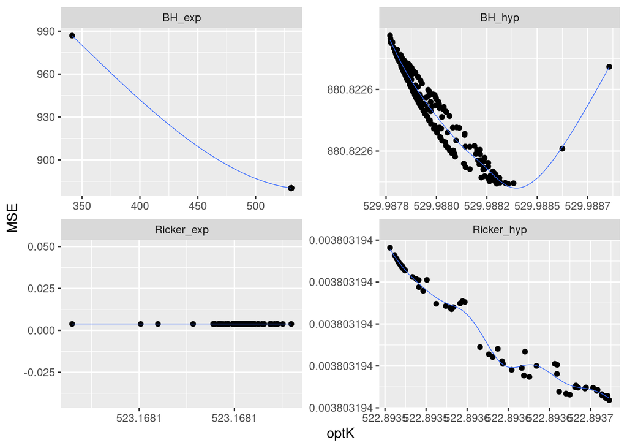

```r
plot_nloptr_lbfgs <- iterate_optim_all(Rmax = seq(0, 1, 1e-3), K = 1/seq(100, 1000, 100), data = pop_size_trunc,
                                       optim_fn = nloptr::lbfgs,
                                       lower = c(0, 1/2000),
                                       upper = c(Inf, 1/100),
                                       control = list(xtol_rel = 1e-7))

plot_iterated_optim_all(plot_nloptr_lbfgs, k = 10, scales = "free")
```

Extract best starting parameters to achieve lowest MSE

```r
plot_nloptr_lbfgs_best <- plot_nloptr_lbfgs %>%
  group_by(type) %>%
  filter(MSE == min(MSE)) %>%
  #If there are the same ones, just take first
  slice(1) %>%
  rowwise() %>%
  mutate(y = list(aggregate_mod(N = plot_range, Rmax = optRmax, K = 1/optK, type = type)),
         x = list(plot_range),
         opt = "NLOPTR_LBFGS") %>%
  ungroup()
```

## nloptr PRAXIS

```r
## TEST IT WORKS AS EXPECTED
#Not optimising well....
(test <- nloptr::nloptr(x0 = c(0, 1/200),
                        eval_f = generic_optim,
                        lb = c(0, 1/2000),
                        ub = c(2, 1/100),
                        data = pop_size_test, type = "Ricker_exp",
                        opts = list(algorithm = "NLOPT_LN_PRAXIS",
                                    #By making maxeval -1 we don't put a limit on number of evaluations
                                    maxeval = -1,
                                    #Minimum printing
                                    print_level = 0,
                                    #Set seed
                                    ranseed = 123)))
```

```
##
## Call:
## nloptr::nloptr(x0 = c(0, 1/200), eval_f = generic_optim, lb = c(0,
##     1/2000), ub = c(2, 1/100), opts = list(algorithm = "NLOPT_LN_PRAXIS",
##     maxeval = -1, print_level = 0, ranseed = 123), data = pop_size_test,
##     type = "Ricker_exp")
##
##
## Minimization using NLopt version 2.7.1
##
## NLopt solver status: 4 ( NLOPT_XTOL_REACHED: Optimization stopped because
## xtol_rel or xtol_abs (above) was reached. )
##
## Number of Iterations....: 146
## Termination conditions:  maxeval: -1
## Number of inequality constraints:  0
## Number of equality constraints:    0
## Optimal value of objective function:  6.46724656160059
## Optimal value of controls: 0.04842324 0.0005001508
```

```r
1/test$solution[2]
```

```
## [1] 1999.397
```

```r
## TEST IT WORKS AS EXPECTED
#Working better....so might be doing better for BH than Ricker
(test <- nloptr::nloptr(x0 = c(0, 1/200),
                        eval_f = generic_optim,
                        lb = c(0, 1/2000),
                        ub = c(2, 1/100),
                        data = pop_size_test, type = "BH_exp",
                        opts = list(algorithm = "NLOPT_LN_PRAXIS",
                                    #By making maxeval -1 we don't put a limit on number of evaluations
                                    maxeval = -1,
                                    #Minimum printing
                                    print_level = 0,
                                    #Set seed
                                    ranseed = 123)))
```

```
##
## Call:
## nloptr::nloptr(x0 = c(0, 1/200), eval_f = generic_optim, lb = c(0,
##     1/2000), ub = c(2, 1/100), opts = list(algorithm = "NLOPT_LN_PRAXIS",
##     maxeval = -1, print_level = 0, ranseed = 123), data = pop_size_test,
##     type = "BH_exp")
##
##
## Minimization using NLopt version 2.7.1
##
## NLopt solver status: 4 ( NLOPT_XTOL_REACHED: Optimization stopped because
## xtol_rel or xtol_abs (above) was reached. )
##
## Number of Iterations....: 293
## Termination conditions:  maxeval: -1
## Number of inequality constraints:  0
## Number of equality constraints:    0
## Optimal value of objective function:  1.13215165192626
## Optimal value of controls: 0.4985062 0.001430881
```

```r
1/test$solution[2]
```

```
## [1] 698.8701
```

Now use to optimize real data.

Ricker exponential

```r
(nloptr_praxis_Rickerexp <- nloptr::nloptr(x0 = c(1, 1/500),
                                           eval_f = generic_optim,
                                           lb = c(0, 1/2000),
                                           ub = c(Inf, 1/100),
                                           data = pop_size_trunc, type = "Ricker_exp",
                                           opts = list(algorithm = "NLOPT_LN_PRAXIS",
                                                       #By making maxeval -1 we don't put a limit on number of evaluations
                                                       maxeval = -1,
                                                       #Minimum printing
                                                       print_level = 0,
                                                       #Set seed
                                                       ranseed = 123)))
```

```
##
## Call:
## nloptr::nloptr(x0 = c(1, 1/500), eval_f = generic_optim, lb = c(0,
##     1/2000), ub = c(Inf, 1/100), opts = list(algorithm = "NLOPT_LN_PRAXIS",
##     maxeval = -1, print_level = 0, ranseed = 123), data = pop_size_trunc,
##     type = "Ricker_exp")
##
##
## Minimization using NLopt version 2.7.1
##
## NLopt solver status: 4 ( NLOPT_XTOL_REACHED: Optimization stopped because
## xtol_rel or xtol_abs (above) was reached. )
##
## Number of Iterations....: 447
## Termination conditions:  maxeval: -1
## Number of inequality constraints:  0
## Number of equality constraints:    0
## Optimal value of objective function:  0.00380075756422751
## Optimal value of controls: 0.09289076 0.001911431
```

```r
paste("K =", 1/nloptr_praxis_Rickerexp$solution[2])
```

```
## [1] "K = 523.168129952714"
```

Ricker hyperbolic

```r
(nloptr_praxis_Rickerhyp <- nloptr::nloptr(x0 = c(1, 1/500),
                                           eval_f = generic_optim,
                                           lb = c(0, 1/2000),
                                           ub = c(Inf, 1/100),
                                           data = pop_size_trunc, type = "Ricker_hyp",
                                           opts = list(algorithm = "NLOPT_LN_PRAXIS",
                                                       #By making maxeval -1 we don't put a limit on number of evaluations
                                                       maxeval = -1,
                                                       #Minimum printing
                                                       print_level = 0,
                                                       #Set seed
                                                       ranseed = 123)))
```

```
##
## Call:
## nloptr::nloptr(x0 = c(1, 1/500), eval_f = generic_optim, lb = c(0,
##     1/2000), ub = c(Inf, 1/100), opts = list(algorithm = "NLOPT_LN_PRAXIS",
##     maxeval = -1, print_level = 0, ranseed = 123), data = pop_size_trunc,
##     type = "Ricker_hyp")
##
##
## Minimization using NLopt version 2.7.1
##
## NLopt solver status: 4 ( NLOPT_XTOL_REACHED: Optimization stopped because
## xtol_rel or xtol_abs (above) was reached. )
##
## Number of Iterations....: 424
## Termination conditions:  maxeval: -1
## Number of inequality constraints:  0
## Number of equality constraints:    0
## Optimal value of objective function:  0.00380319434240852
## Optimal value of controls: 0.0952615 0.001912437
```

```r
paste("K =", 1/nloptr_praxis_Rickerhyp$solution[2])
```

```
## [1] "K = 522.893048906992"
```

Beverton-Holt exponential

```r
(nloptr_praxis_BHexp <- nloptr::nloptr(x0 = c(1, 1/500),
                                       eval_f = generic_optim,
                                       lb = c(0, 1/2000),
                                       ub = c(Inf, 1/100),
                                       data = pop_size_trunc, type = "BH_exp",
                                       opts = list(algorithm = "NLOPT_LN_PRAXIS",
                                                   #By making maxeval -1 we don't put a limit on number of evaluations
                                                   maxeval = -1,
                                                   #Minimum printing
                                                   print_level = 0,
                                                   #Set seed
                                                   ranseed = 123)))
```

```
##
## Call:
## nloptr::nloptr(x0 = c(1, 1/500), eval_f = generic_optim, lb = c(0,
##     1/2000), ub = c(Inf, 1/100), opts = list(algorithm = "NLOPT_LN_PRAXIS",
##     maxeval = -1, print_level = 0, ranseed = 123), data = pop_size_trunc,
##     type = "BH_exp")
##
##
## Minimization using NLopt version 2.7.1
##
## NLopt solver status: 4 ( NLOPT_XTOL_REACHED: Optimization stopped because
## xtol_rel or xtol_abs (above) was reached. )
##
## Number of Iterations....: 429
## Termination conditions:  maxeval: -1
## Number of inequality constraints:  0
## Number of equality constraints:    0
## Optimal value of objective function:  880.277958590972
## Optimal value of controls: 0.1037113 0.001883991
```

```r
paste("K =", 1/nloptr_praxis_BHexp$solution[2])
```

```
## [1] "K = 530.788137394884"
```

Beverton-Holt hyperbolic

```r
(nloptr_praxis_BHhyp <- nloptr::nloptr(x0 = c(1, 1/500),
                                       eval_f = generic_optim,
                                       lb = c(0, 1/2000),
                                       ub = c(Inf, 1/100),
                                       data = pop_size_trunc, type = "BH_hyp",
                                       opts = list(algorithm = "NLOPT_LN_PRAXIS",
                                                   #By making maxeval -1 we don't put a limit on number of evaluations
                                                   maxeval = -1,
                                                   #Minimum printing
                                                   print_level = 0,
                                                   #Set seed
                                                   ranseed = 123)))
```

```
##
## Call:
## nloptr::nloptr(x0 = c(1, 1/500), eval_f = generic_optim, lb = c(0,
##     1/2000), ub = c(Inf, 1/100), opts = list(algorithm = "NLOPT_LN_PRAXIS",
##     maxeval = -1, print_level = 0, ranseed = 123), data = pop_size_trunc,
##     type = "BH_hyp")
##
##
## Minimization using NLopt version 2.7.1
##
## NLopt solver status: 4 ( NLOPT_XTOL_REACHED: Optimization stopped because
## xtol_rel or xtol_abs (above) was reached. )
##
## Number of Iterations....: 473
## Termination conditions:  maxeval: -1
## Number of inequality constraints:  0
## Number of equality constraints:    0
## Optimal value of objective function:  880.82261356947
## Optimal value of controls: 0.1072903 0.001886834
```

```r
paste("K =", 1/nloptr_praxis_BHhyp$solution[2])
```

```
## [1] "K = 529.988300959592"
```

Test how sensititive this is to optimizers starting values.

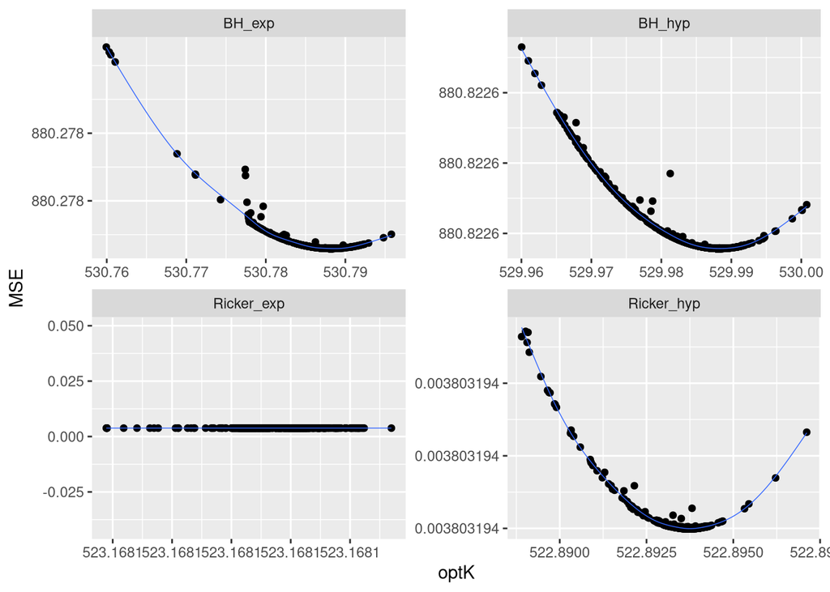

```r
plot_nloptr_praxis <- iterate_optim_all(Rmax = seq(0, 1, 1e-3), K = 1/seq(100, 1000, 100), data = pop_size_trunc,
                                        optim_fn = nloptr::nloptr,
                                        lb = c(0, 1/2000),
                                        ub = c(Inf, 1/100),
                                        opts = list(algorithm = "NLOPT_LN_PRAXIS",
                                                    #By making maxeval -1 we don't put a limit on number of evaluations
                                                    maxeval = -1,
                                                    #Found that fixing xtol_abs for Rmax helps with Ricker sensitivity a bit
                                                    xtol_abs = c(1e-4, 0),
                                                    #Minimum printing
                                                    print_level = 0,
                                                    #Set seed
                                                    ranseed = 123))

#As expected (from fitting on test data), seems to work much better with BH than Ricker
plot_iterated_optim_all(plot_nloptr_praxis, k = 10, scales = "free")
```

Extract best starting parameters to achieve lowest MSE

```r
plot_nloptr_praxis_best <- plot_nloptr_praxis %>%
  group_by(type) %>%
  filter(MSE == min(MSE)) %>%
  slice(1) %>%
  rowwise() %>%
  mutate(y = list(aggregate_mod(N = plot_range, Rmax = optRmax, K = 1/optK, type = type)),
         x = list(plot_range),
         opt = "NLOPTR_PRAXIS") %>%
  ungroup()
```

## nloptr Nelder-Mead

```r
## TEST IT WORKS AS EXPECTED
#Failing with Ricker...
(test <- nloptr::nloptr(x0 = c(0, 1/200),
                        eval_f = generic_optim,
                        lb = c(0, 1/2000),
                        ub = c(2, 1/100),
                        data = pop_size_test, type = "Ricker_exp",
                        opts = list(algorithm = "NLOPT_LN_NELDERMEAD",
                                    #By making maxeval -1 we don't put a limit on number of evaluations
                                    maxeval = -1,
                                    #Minimum printing
                                    print_level = 0,
                                    #Set seed
                                    ranseed = 123)))
```

```
##
## Call:
## nloptr::nloptr(x0 = c(0, 1/200), eval_f = generic_optim, lb = c(0,
##     1/2000), ub = c(2, 1/100), opts = list(algorithm = "NLOPT_LN_NELDERMEAD",
##     maxeval = -1, print_level = 0, ranseed = 123), data = pop_size_test,
##     type = "Ricker_exp")
##
##
## Minimization using NLopt version 2.7.1
##
## NLopt solver status: 4 ( NLOPT_XTOL_REACHED: Optimization stopped because
## xtol_rel or xtol_abs (above) was reached. )
##
## Number of Iterations....: 16
## Termination conditions:  maxeval: -1
## Number of inequality constraints:  0
## Number of equality constraints:    0
## Optimal value of objective function:  3.30428083512635
## Optimal value of controls: 2 5e-04
```

```r
1/test$solution[2]
```

```
## [1] 2000
```

```r
## TEST IT WORKS AS EXPECTED
#Looks ok
(test <- nloptr::nloptr(x0 = c(0, 1/200),
                        eval_f = generic_optim,
                        lb = c(0, 1/2000),
                        ub = c(2, 1/100),
                        data = pop_size_test, type = "BH_exp",
                        opts = list(algorithm = "NLOPT_LN_NELDERMEAD",
                                    #By making maxeval -1 we don't put a limit on number of evaluations
                                    maxeval = -1,
                                    #Minimum printing
                                    print_level = 0,
                                    #Set seed
                                    ranseed = 123)))
```

```
##
## Call:
## nloptr::nloptr(x0 = c(0, 1/200), eval_f = generic_optim, lb = c(0,
##     1/2000), ub = c(2, 1/100), opts = list(algorithm = "NLOPT_LN_NELDERMEAD",
##     maxeval = -1, print_level = 0, ranseed = 123), data = pop_size_test,
##     type = "BH_exp")
##
##
## Minimization using NLopt version 2.7.1
##
## NLopt solver status: 4 ( NLOPT_XTOL_REACHED: Optimization stopped because
## xtol_rel or xtol_abs (above) was reached. )
##
## Number of Iterations....: 136
## Termination conditions:  maxeval: -1
## Number of inequality constraints:  0
## Number of equality constraints:    0
## Optimal value of objective function:  1.13217005692484
## Optimal value of controls: 0.4985115 0.001430901
```

```r
1/test$solution[2]
```

```
## [1] 698.8604
```

Now use to optimize real data.

Ricker exponential

```r
(nloptr_neldermead_Rickerexp <- nloptr::nloptr(x0 = c(1, 1/500),
                                               eval_f = generic_optim,
                                               lb = c(0, 1/2000),
                                               ub = c(Inf, 1/100),
                                               data = pop_size_trunc, type = "Ricker_exp",
                                               opts = list(algorithm = "NLOPT_LN_NELDERMEAD",
                                                           #By making maxeval -1 we don't put a limit on number of evaluations
                                                           maxeval = -1,
                                                           #Minimum printing
                                                           print_level = 0,
                                                           #Set seed
                                                           ranseed = 123)))
```

```
##
## Call:
## nloptr::nloptr(x0 = c(1, 1/500), eval_f = generic_optim, lb = c(0,
##     1/2000), ub = c(Inf, 1/100), opts = list(algorithm = "NLOPT_LN_NELDERMEAD",
##     maxeval = -1, print_level = 0, ranseed = 123), data = pop_size_trunc,
##     type = "Ricker_exp")
##
##
## Minimization using NLopt version 2.7.1
##
## NLopt solver status: 4 ( NLOPT_XTOL_REACHED: Optimization stopped because
## xtol_rel or xtol_abs (above) was reached. )
##
## Number of Iterations....: 102
## Termination conditions:  maxeval: -1
## Number of inequality constraints:  0
## Number of equality constraints:    0
## Optimal value of objective function:  0.00380075756854233
## Optimal value of controls: 0.09288433 0.001911395
```

```r
paste("K =", 1/nloptr_neldermead_Rickerexp$solution[2])
```

```
## [1] "K = 523.178162732213"
```

Ricker hyperbolic

```r
(nloptr_neldermead_Rickerhyp <- nloptr::nloptr(x0 = c(1, 1/500),
                                               eval_f = generic_optim,
                                               lb = c(0, 1/2000),
                                               ub = c(Inf, 1/100),
                                               data = pop_size_trunc, type = "Ricker_hyp",
                                               opts = list(algorithm = "NLOPT_LN_NELDERMEAD",
                                                           #By making maxeval -1 we don't put a limit on number of evaluations
                                                           maxeval = -1,
                                                           #Minimum printing
                                                           print_level = 0,
                                                           #Set seed
                                                           ranseed = 123)))
```

```
##
## Call:
## nloptr::nloptr(x0 = c(1, 1/500), eval_f = generic_optim, lb = c(0,
##     1/2000), ub = c(Inf, 1/100), opts = list(algorithm = "NLOPT_LN_NELDERMEAD",
##     maxeval = -1, print_level = 0, ranseed = 123), data = pop_size_trunc,
##     type = "Ricker_hyp")
##
##
## Minimization using NLopt version 2.7.1
##
## NLopt solver status: 4 ( NLOPT_XTOL_REACHED: Optimization stopped because
## xtol_rel or xtol_abs (above) was reached. )
##
## Number of Iterations....: 105
## Termination conditions:  maxeval: -1
## Number of inequality constraints:  0
## Number of equality constraints:    0
## Optimal value of objective function:  0.00380319434335151
## Optimal value of controls: 0.09525844 0.001912415
```

```r
paste("K =", 1/nloptr_neldermead_Rickerhyp$solution[2])
```

```
## [1] "K = 522.899148896179"
```

Beverton-Holt exponential

```r
(nloptr_neldermead_BHexp <- nloptr::nloptr(x0 = c(1, 1/500),
                                           eval_f = generic_optim,
                                           lb = c(0, 1/2000),
                                           ub = c(Inf, 1/100),
                                           data = pop_size_trunc, type = "BH_exp",
                                           opts = list(algorithm = "NLOPT_LN_NELDERMEAD",
                                                       #By making maxeval -1 we don't put a limit on number of evaluations
                                                       maxeval = -1,
                                                       #Minimum printing
                                                       print_level = 0,
                                                       #Set seed
                                                       ranseed = 123)))
```

```
##
## Call:
## nloptr::nloptr(x0 = c(1, 1/500), eval_f = generic_optim, lb = c(0,
##     1/2000), ub = c(Inf, 1/100), opts = list(algorithm = "NLOPT_LN_NELDERMEAD",
##     maxeval = -1, print_level = 0, ranseed = 123), data = pop_size_trunc,
##     type = "BH_exp")
##
##
## Minimization using NLopt version 2.7.1
##
## NLopt solver status: 4 ( NLOPT_XTOL_REACHED: Optimization stopped because
## xtol_rel or xtol_abs (above) was reached. )
##
## Number of Iterations....: 116
## Termination conditions:  maxeval: -1
## Number of inequality constraints:  0
## Number of equality constraints:    0
## Optimal value of objective function:  880.277958818888
## Optimal value of controls: 0.1037075 0.001883978
```

```r
paste("K =", 1/nloptr_neldermead_BHexp$solution[2])
```

```
## [1] "K = 530.791687760439"
```

Beverton-Holt hyperbolic

```r
(nloptr_neldermead_BHhyp <- nloptr::nloptr(x0 = c(1, 1/500),
                                           eval_f = generic_optim,
                                           lb = c(0, 1/2000),
                                           ub = c(Inf, 1/100),
                                           data = pop_size_trunc, type = "BH_hyp",
                                           opts = list(algorithm = "NLOPT_LN_NELDERMEAD",
                                                       #By making maxeval -1 we don't put a limit on number of evaluations
                                                       maxeval = -1,
                                                       #Minimum printing
                                                       print_level = 0,
                                                       #Set seed
                                                       ranseed = 123)))
```

```
##
## Call:
## nloptr::nloptr(x0 = c(1, 1/500), eval_f = generic_optim, lb = c(0,
##     1/2000), ub = c(Inf, 1/100), opts = list(algorithm = "NLOPT_LN_NELDERMEAD",
##     maxeval = -1, print_level = 0, ranseed = 123), data = pop_size_trunc,
##     type = "BH_hyp")
##
##
## Minimization using NLopt version 2.7.1
##
## NLopt solver status: 4 ( NLOPT_XTOL_REACHED: Optimization stopped because
## xtol_rel or xtol_abs (above) was reached. )
##
## Number of Iterations....: 112
## Termination conditions:  maxeval: -1
## Number of inequality constraints:  0
## Number of equality constraints:    0
## Optimal value of objective function:  880.822613771339
## Optimal value of controls: 0.1072944 0.001886845
```

```r
paste("K =", 1/nloptr_neldermead_BHhyp$solution[2])
```

```
## [1] "K = 529.985341930376"
```

Test how sensititive this is to optimizers starting values.

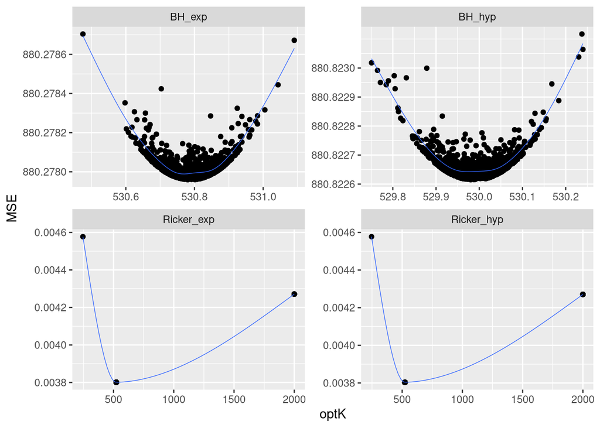

```r
plot_nloptr_neldermead <- iterate_optim_all(Rmax = seq(0, 1, 1e-3), K = 1/seq(100, 1000, 100), data = pop_size_trunc,
                                            optim_fn = nloptr::nloptr,
                                            lb = c(0, 1/2000),
                                            ub = c(Inf, 1/100),
                                            opts = list(algorithm = "NLOPT_LN_NELDERMEAD",
                                                        #By making maxeval -1 we don't put a limit on number of evaluations
                                                        maxeval = -1,
                                                        #Found that fixing xtol_abs helps a bit with Ricker sensitivity to starting vals
                                                        xtol_abs = c(1e-4, 0),
                                                        #Minimum printing
                                                        print_level = 0,
                                                        #Set seed
                                                        ranseed = 123))

#Again, works much better for BH than Ricker
plot_iterated_optim_all(plot_nloptr_neldermead, k = 10)
```

Extract best starting parameters to achieve lowest MSE

```r
plot_nloptr_neldermead_best <- plot_nloptr_neldermead %>%
  group_by(type) %>%
  filter(MSE == min(MSE)) %>%
  rowwise() %>%
  mutate(y = list(aggregate_mod(N = plot_range, Rmax = optRmax, K = 1/optK, type = type)),
         opt = "NLOPTR_NELDERMEAD") %>%
  ungroup()
```

## nloptr Sbplx

```r
## TEST IT WORKS AS EXPECTED
#Looks ok
(test <- nloptr::nloptr(x0 = c(0, 1/200),
                        eval_f = generic_optim,
                        lb = c(0, 1/2000),
                        ub = c(2, 1/100),
                        data = pop_size_test, type = "Ricker_exp",
                        opts = list(algorithm = "NLOPT_LN_SBPLX",
                                    #By making maxeval -1 we don't put a limit on number of evaluations
                                    maxeval = -1,
                                    #Minimum printing
                                    print_level = 0,
                                    #Set seed
                                    ranseed = 123)))
```

```
##
## Call:
## nloptr::nloptr(x0 = c(0, 1/200), eval_f = generic_optim, lb = c(0,
##     1/2000), ub = c(2, 1/100), opts = list(algorithm = "NLOPT_LN_SBPLX",
##     maxeval = -1, print_level = 0, ranseed = 123), data = pop_size_test,
##     type = "Ricker_exp")
##
##
## Minimization using NLopt version 2.7.1
##
## NLopt solver status: 4 ( NLOPT_XTOL_REACHED: Optimization stopped because
## xtol_rel or xtol_abs (above) was reached. )
##
## Number of Iterations....: 42
## Termination conditions:  maxeval: -1
## Number of inequality constraints:  0
## Number of equality constraints:    0
## Optimal value of objective function:  2.51557905713614
## Optimal value of controls: 2 0.001276978
```

```r
1/test$solution[2]
```

```
## [1] 783.0991
```

```r
## TEST IT WORKS AS EXPECTED
#Looks ok
(test <- nloptr::nloptr(x0 = c(0, 1/200),
                        eval_f = generic_optim,
                        lb = c(0, 1/2000),
                        ub = c(2, 1/100),
                        data = pop_size_test, type = "BH_exp",
                        opts = list(algorithm = "NLOPT_LN_SBPLX",
                                    #By making maxeval -1 we don't put a limit on number of evaluations
                                    maxeval = -1,
                                    #Minimum printing
                                    print_level = 0,
                                    #Set seed
                                    ranseed = 123)))
```

```
##
## Call:
## nloptr::nloptr(x0 = c(0, 1/200), eval_f = generic_optim, lb = c(0,
##     1/2000), ub = c(2, 1/100), opts = list(algorithm = "NLOPT_LN_SBPLX",
##     maxeval = -1, print_level = 0, ranseed = 123), data = pop_size_test,
##     type = "BH_exp")
##
##
## Minimization using NLopt version 2.7.1
##
## NLopt solver status: 4 ( NLOPT_XTOL_REACHED: Optimization stopped because
## xtol_rel or xtol_abs (above) was reached. )
##
## Number of Iterations....: 244
## Termination conditions:  maxeval: -1
## Number of inequality constraints:  0
## Number of equality constraints:    0
## Optimal value of objective function:  1.13215165189406
## Optimal value of controls: 0.4985063 0.001430881
```

```r
1/test$solution[2]
```

```
## [1] 698.8701
```

Now use to optimize real data.

Ricker exponential

```r
(nloptr_sbplx_Rickerexp <- nloptr::nloptr(x0 = c(1, 1/500),
                                          eval_f = generic_optim,
                                          lb = c(0, 1/2000),
                                          ub = c(Inf, 1/100),
                                          data = pop_size_trunc, type = "Ricker_exp",
                                          opts = list(algorithm = "NLOPT_LN_SBPLX",
                                                      #By making maxeval -1 we don't put a limit on number of evaluations
                                                      maxeval = -1,
                                                      #Minimum printing
                                                      print_level = 0,
                                                      #Set seed
                                                      ranseed = 123)))
```

```
##
## Call:
## nloptr::nloptr(x0 = c(1, 1/500), eval_f = generic_optim, lb = c(0,
##     1/2000), ub = c(Inf, 1/100), opts = list(algorithm = "NLOPT_LN_SBPLX",
##     maxeval = -1, print_level = 0, ranseed = 123), data = pop_size_trunc,
##     type = "Ricker_exp")
##
##
## Minimization using NLopt version 2.7.1
##
## NLopt solver status: 4 ( NLOPT_XTOL_REACHED: Optimization stopped because
## xtol_rel or xtol_abs (above) was reached. )
##
## Number of Iterations....: 150
## Termination conditions:  maxeval: -1
## Number of inequality constraints:  0
## Number of equality constraints:    0
## Optimal value of objective function:  0.00380075756562221
## Optimal value of controls: 0.09289141 0.00191146
```

```r
paste("K =", 1/nloptr_sbplx_Rickerexp$solution[2])
```

```
## [1] "K = 523.160181051528"
```

Ricker hyperbolic

```r
(nloptr_sbplx_Rickerhyp <- nloptr::nloptr(x0 = c(1, 1/500),
                                          eval_f = generic_optim,
                                          lb = c(0, 1/2000),
                                          ub = c(Inf, 1/100),
                                          data = pop_size_trunc, type = "Ricker_hyp",
                                          opts = list(algorithm = "NLOPT_LN_SBPLX",
                                                      #By making maxeval -1 we don't put a limit on number of evaluations
                                                      maxeval = -1,
                                                      #Minimum printing
                                                      print_level = 0,
                                                      #Set seed
                                                      ranseed = 123)))
```

```
##
## Call:
## nloptr::nloptr(x0 = c(1, 1/500), eval_f = generic_optim, lb = c(0,
##     1/2000), ub = c(Inf, 1/100), opts = list(algorithm = "NLOPT_LN_SBPLX",
##     maxeval = -1, print_level = 0, ranseed = 123), data = pop_size_trunc,
##     type = "Ricker_hyp")
##
##
## Minimization using NLopt version 2.7.1
##
## NLopt solver status: 4 ( NLOPT_XTOL_REACHED: Optimization stopped because
## xtol_rel or xtol_abs (above) was reached. )
##
## Number of Iterations....: 123
## Termination conditions:  maxeval: -1
## Number of inequality constraints:  0
## Number of equality constraints:    0
## Optimal value of objective function:  0.00380319437655323
## Optimal value of controls: 0.09527668 0.001912569
```

```r
paste("K =", 1/nloptr_sbplx_Rickerhyp$solution[2])
```

```
## [1] "K = 522.856987309418"
```

Beverton-Holt exponential

```r
(nloptr_sbplx_BHexp <- nloptr::nloptr(x0 = c(1, 1/500),
                                      eval_f = generic_optim,
                                      lb = c(0, 1/2000),
                                      ub = c(Inf, 1/100),
                                      data = pop_size_trunc, type = "BH_exp",
                                      opts = list(algorithm = "NLOPT_LN_SBPLX",
                                                  #By making maxeval -1 we don't put a limit on number of evaluations
                                                  maxeval = -1,
                                                  #Minimum printing
                                                  print_level = 0,
                                                  #Set seed
                                                  ranseed = 123)))
```

```
##
## Call:
## nloptr::nloptr(x0 = c(1, 1/500), eval_f = generic_optim, lb = c(0,
##     1/2000), ub = c(Inf, 1/100), opts = list(algorithm = "NLOPT_LN_SBPLX",
##     maxeval = -1, print_level = 0, ranseed = 123), data = pop_size_trunc,
##     type = "BH_exp")
##
##
## Minimization using NLopt version 2.7.1
##
## NLopt solver status: 4 ( NLOPT_XTOL_REACHED: Optimization stopped because
## xtol_rel or xtol_abs (above) was reached. )
##
## Number of Iterations....: 174
## Termination conditions:  maxeval: -1
## Number of inequality constraints:  0
## Number of equality constraints:    0
## Optimal value of objective function:  880.277959810283
## Optimal value of controls: 0.1037129 0.001884036
```

```r
paste("K =", 1/nloptr_sbplx_BHexp$solution[2])
```

```
## [1] "K = 530.775522494393"
```

Beverton-Holt hyperbolic

```r
(nloptr_sbplx_BHhyp <- nloptr::nloptr(x0 = c(1, 1/500),
                                      eval_f = generic_optim,
                                      lb = c(0, 1/2000),
                                      ub = c(Inf, 1/100),
                                      data = pop_size_trunc, type = "BH_hyp",
                                      opts = list(algorithm = "NLOPT_LN_SBPLX",
                                                  #By making maxeval -1 we don't put a limit on number of evaluations
                                                  maxeval = -1,
                                                  #Minimum printing
                                                  print_level = 0,
                                                  #Set seed
                                                  ranseed = 123)))
```

```
##
## Call:
## nloptr::nloptr(x0 = c(1, 1/500), eval_f = generic_optim, lb = c(0,
##     1/2000), ub = c(Inf, 1/100), opts = list(algorithm = "NLOPT_LN_SBPLX",
##     maxeval = -1, print_level = 0, ranseed = 123), data = pop_size_trunc,
##     type = "BH_hyp")
##
##
## Minimization using NLopt version 2.7.1
##
## NLopt solver status: 4 ( NLOPT_XTOL_REACHED: Optimization stopped because
## xtol_rel or xtol_abs (above) was reached. )
##
## Number of Iterations....: 180
## Termination conditions:  maxeval: -1
## Number of inequality constraints:  0
## Number of equality constraints:    0
## Optimal value of objective function:  880.822613572753
## Optimal value of controls: 0.1072899 0.001886832
```

```r
paste("K =", 1/nloptr_sbplx_BHhyp$solution[2])
```

```
## [1] "K = 529.988907516459"
```

Test how sensititive this is to optimizers starting values.

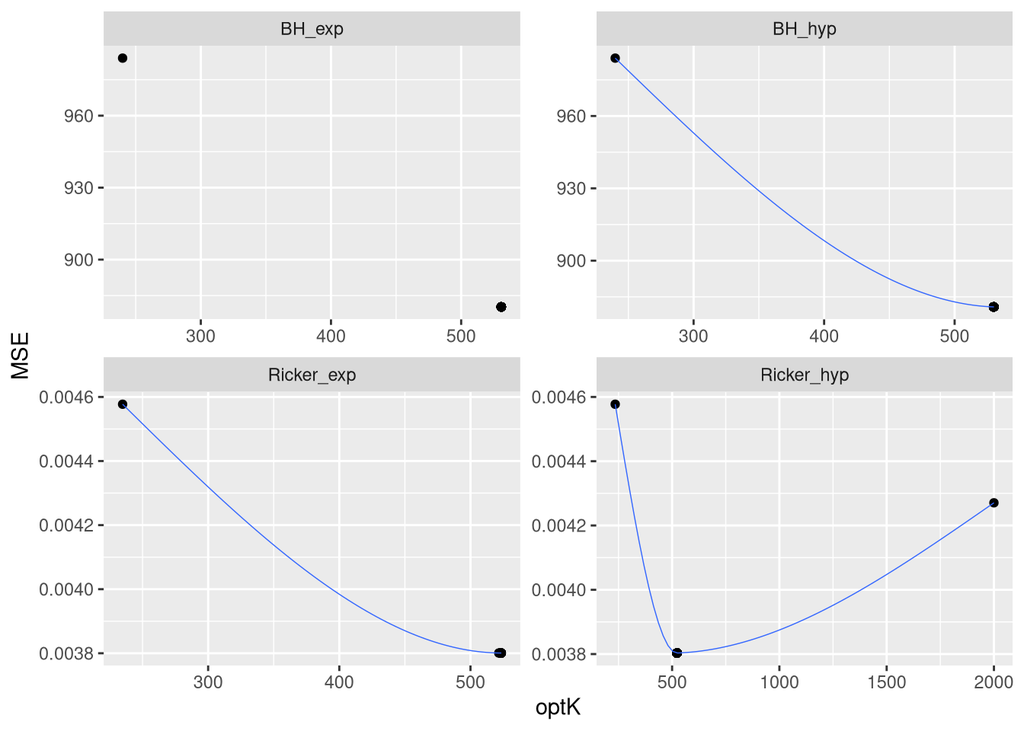

```r
plot_nloptr_sbplx <- iterate_optim_all(Rmax = seq(0, 1, 1e-3), K = 1/seq(100, 1000, 100), data = pop_size_trunc,
                                       optim_fn = nloptr::nloptr,
                                       lb = c(0, 1/2000),
                                       ub = c(Inf, 1/100),
                                       opts = list(algorithm = "NLOPT_LN_SBPLX",
                                                   #By making maxeval -1 we don't put a limit on number of evaluations
                                                   maxeval = -1,
                                                   #Adjusting xtol_abs for Rmax seems to reduce sensitiivty
                                                   xtol_abs = c(1e-5, 0),
                                                   #Minimum printing
                                                   print_level = 0,
                                                   #Set seed
                                                   ranseed = 123))

plot_iterated_optim_all(plot_nloptr_sbplx, k = 10)
```

Extract best starting parameters to achieve lowest MSE

```r
plot_nloptr_sbplx_best <- plot_nloptr_sbplx %>%
  group_by(type) %>%
  filter(MSE == min(MSE)) %>%
  slice(1) %>%
  rowwise() %>%
  mutate(y = list(aggregate_mod(N = plot_range, Rmax = optRmax, K = 1/optK, type = type)),
         x = list(plot_range),
         opt = "NLOPTR_SBPLX") %>%
  ungroup()
```

## minqa bobyqa

```r
## TEST IT WORKS AS EXPECTED
#Looks ok
(test <- minqa::bobyqa(c(0, 1/200),
                       generic_optim,
                       lower = c(0, 1/2000),
                       upper = c(2, 1/100),
                       data = pop_size_test, type = "Ricker_exp"))
```

```
## parameter estimates: 2, 0.00127684814114855
## objective: 2.51557903525373
## number of function evaluations: 48
```

```r
1/test$par[2]
```

```
## [1] 783.1785
```

```r
## TEST IT WORKS AS EXPECTED
#Looks ok
(test <- minqa::bobyqa(c(0, 1/200),
                       generic_optim,
                       lower = c(0, 1/2000),
                       upper = c(2, 1/100),
                       data = pop_size_test, type = "BH_exp"))
```

```
## parameter estimates: 0.498506260906036, 0.00143088111878106
## objective: 1.13215165189575
## number of function evaluations: 3195
```

```r
1/test$par[2]
```

```
## [1] 698.8701
```

Now use to optimize real data.

Ricker exponential

```r
(minqa_bobyqa_Rickerexp <- minqa::bobyqa(c(0, 1/200),
                                         generic_optim,
                                         lower = c(0, 1/2000),
                                         upper = c(2, 1/100),
                                         data = pop_size_trunc, type = "Ricker_exp"))
```

```
## parameter estimates: 0, 0.005
## objective: 0.00457730778528117
## number of function evaluations: 14
```

```r
paste("K =", 1/minqa_bobyqa_Rickerexp$par[2])
```

```
## [1] "K = 200"
```

Ricker hyperbolic

```r
(minqa_bobyqa_Rickerhyp <- minqa::bobyqa(c(0, 1/200),
                                         generic_optim,
                                         lower = c(0, 1/2000),
                                         upper = c(2, 1/100),
                                         data = pop_size_trunc, type = "Ricker_hyp"))
```

```
## parameter estimates: 0, 0.005
## objective: 0.00457730778528117
## number of function evaluations: 14
```

```r
paste("K =", 1/minqa_bobyqa_Rickerhyp$par[2])
```

```
## [1] "K = 200"
```

Beverton-Holt exponential

```r
(minqa_bobyqa_BHexp <- minqa::bobyqa(c(0, 1/200),
                                     generic_optim,
                                     lower = c(0, 1/2000),
                                     upper = c(2, 1/100),
                                     data = pop_size_trunc, type = "BH_exp"))
```

```
## parameter estimates: 0.103711292513771, 0.00188399042233954
## objective: 880.277958590858
## number of function evaluations: 664
```

```r
paste("K =", 1/minqa_bobyqa_BHexp$par[2])
```

```
## [1] "K = 530.788260992431"
```

Beverton-Holt hyperbolic

```r
(minqa_bobyqa_BHhyp <- minqa::bobyqa(c(0, 1/200),
                                     generic_optim,
                                     lower = c(0, 1/2000),
                                     upper = c(2, 1/100),
                                     data = pop_size_trunc, type = "BH_hyp"))
```

```
## parameter estimates: 0.10728949274175, 0.00188683371064916
## objective: 880.822613575257
## number of function evaluations: 323
```

```r
paste("K =", 1/minqa_bobyqa_BHhyp$par[2])
```

```
## [1] "K = 529.988410932065"
```

Test how sensititive this is to optimizers starting values.

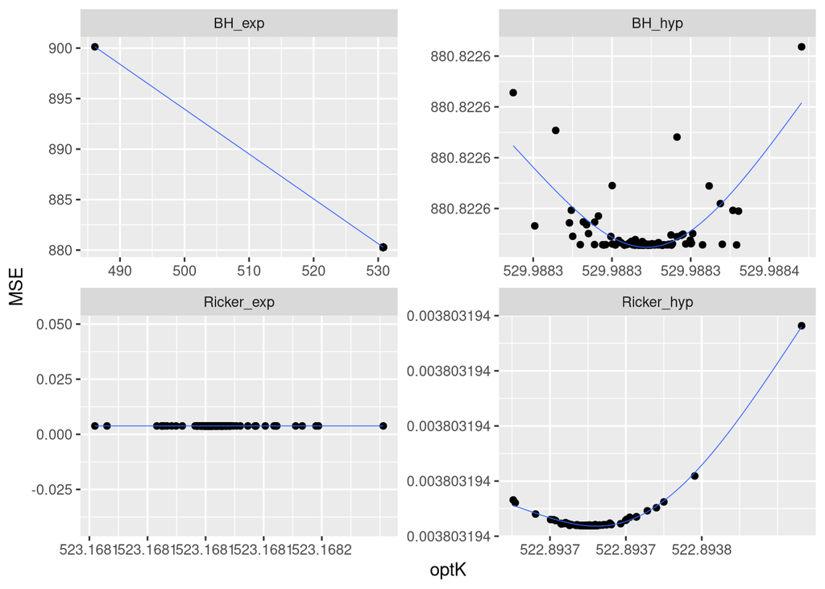

```r
#Reduce step sizes because fit takes much longer
plot_minqa_bobyqa <- iterate_optim_all(Rmax = seq(0, 1, 1e-2), K = 1/seq(100, 1000, 200), data = pop_size_trunc,
                                       optim_fn = minqa::bobyqa,
                                       lower = c(0, 1/2000),
                                       upper = c(Inf, 1/100),
                                       control = list(rhobeg = 1e-5))

plot_iterated_optim_all(plot_minqa_bobyqa, k = 3)
```

Extract best starting parameters to achieve lowest MSE

```r
plot_minqa_bobyqa_best <- plot_minqa_bobyqa %>%
  group_by(type) %>%
  filter(MSE == min(MSE)) %>%
  slice(1) %>%
  rowwise() %>%
  mutate(y = list(aggregate_mod(N = plot_range, Rmax = optRmax, K = 1/optK, type = type)),
         x = list(plot_range),
         opt = "MINQA_BOBYQA") %>%
  ungroup()
```

## nlminb

```r
## TEST IT WORKS AS EXPECTED
#Looks ok
(test <- nlminb(c(0, 1/200),
                generic_optim,
                lower = c(0, 1/2000),
                upper = c(2, 1/100),
                data = pop_size_test, type = "Ricker_exp"))
```

```
## $par
## [1] 2.000000000 0.001276849
##
## $objective
## [1] 2.515579
##
## $convergence
## [1] 0
##
## $iterations
## [1] 7
##
## $evaluations
## function gradient
##       10       18
##
## $message
## [1] "both X-convergence and relative convergence (5)"
```

```r
1/test$par[2]
```

```
## [1] 783.1782
```

```r
## TEST IT WORKS AS EXPECTED
#Looks ok
(test <- nlminb(c(0, 1/200),
                generic_optim,
                lower = c(0, 1/2000),
                upper = c(2, 1/100),
                data = pop_size_test, type = "BH_exp"))
```

```
## $par
## [1] 0.498506250 0.001430881
##
## $objective
## [1] 1.132152
##
## $convergence
## [1] 0
##
## $iterations
## [1] 19
##
## $evaluations
## function gradient
##       39       42
##
## $message
## [1] "X-convergence (3)"
```

```r
1/test$par[2]
```

```
## [1] 698.8701
```

Now use to optimize real data.

Ricker exponential

```r
(nlminb_Rickerexp <- nlminb(c(0, 1/200),
                            generic_optim,
                            lower = c(0, 1/2000),
                            upper = c(2, 1/100),
                            data = pop_size_trunc, type = "Ricker_exp"))
```

```
## $par
## [1] 0.000 0.005
##
## $objective
## [1] 0.004577308
##
## $convergence
## [1] 0
##
## $iterations
## [1] 1
##
## $evaluations
## function gradient
##        1        2
##
## $message
## [1] "both X-convergence and relative convergence (5)"
```

```r
paste("K =", 1/nlminb_Rickerexp$par[2])
```

```
## [1] "K = 200"
```

Ricker hyperbolic

```r
(nlminb_Rickerhyp <- nlminb(c(0, 1/200),
                            generic_optim,
                            lower = c(0, 1/2000),
                            upper = c(2, 1/100),
                            data = pop_size_trunc, type = "Ricker_hyp"))
```

```
## $par
## [1] 0.000 0.005
##
## $objective
## [1] 0.004577308
##
## $convergence
## [1] 0
##
## $iterations
## [1] 1
##
## $evaluations
## function gradient
##        1        2
##
## $message
## [1] "both X-convergence and relative convergence (5)"
```

```r
paste("K =", 1/nlminb_Rickerhyp$par[2])
```

```
## [1] "K = 200"
```

Beverton-Holt exponential

```r
(nlminb_BHexp <- nlminb(c(0, 1/200),
                        generic_optim,
                        lower = c(0, 1/2000),
                        upper = c(2, 1/100),
                        data = pop_size_trunc, type = "BH_exp"))
```

```
## $par
## [1] 0.10371129 0.00188399
##
## $objective
## [1] 880.278
##
## $convergence
## [1] 0
##
## $iterations
## [1] 17
##
## $evaluations
## function gradient
##       42       45
##
## $message
## [1] "relative convergence (4)"
```

```r
paste("K =", 1/nlminb_BHexp$par[2])
```

```
## [1] "K = 530.788259941176"
```

Beverton-Holt hyperbolic

```r
(nlminb_BHhyp <- nlminb(c(0, 1/200),
                        generic_optim,
                        lower = c(0, 1/2000),
                        upper = c(2, 1/100),
                        data = pop_size_trunc, type = "BH_hyp"))
```

```
## $par
## [1] 0.107290307 0.001886834
##
## $objective
## [1] 880.8226
##
## $convergence
## [1] 0
##
## $iterations
## [1] 21
##
## $evaluations
## function gradient
##       52       51
##
## $message
## [1] "relative convergence (4)"
```

```r
paste("K =", 1/nlminb_BHhyp$par[2])
```

```
## [1] "K = 529.988345114951"
```

Test how sensititive this is to optimizers starting values.

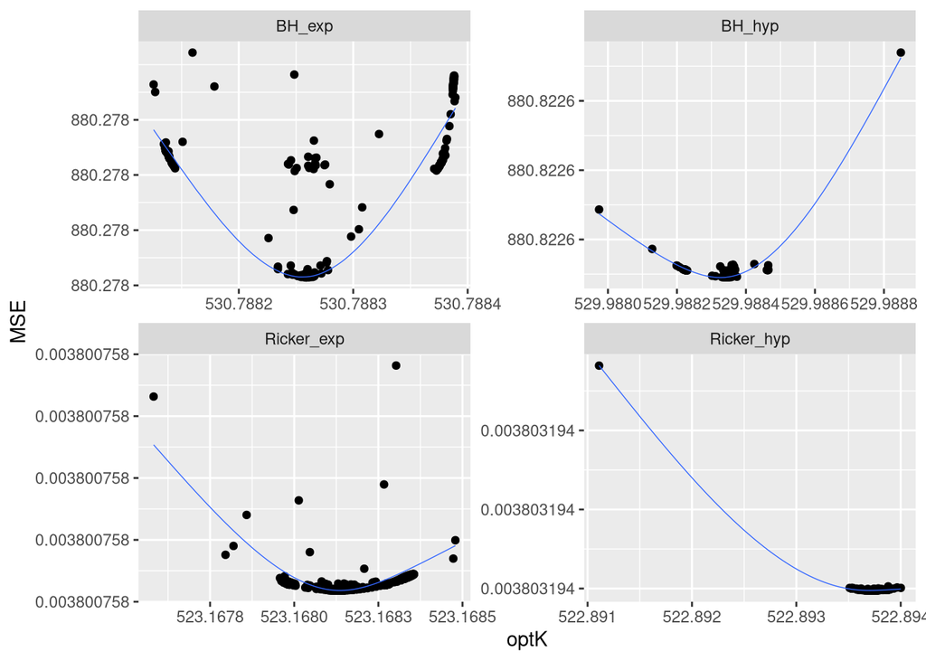

```r
plot_nlminb <- iterate_optim_all(Rmax = seq(0, 1, 1e-3), K = 1/seq(100, 1000, 100), data = pop_size_trunc,
                                 optim_fn = nlminb,
                                 lower = c(0, 1/2000),
                                 upper = c(Inf, 1/100))

plot_iterated_optim_all(plot_nlminb, k = 3)
```

Extract best starting parameters to achieve lowest MSE

```r
plot_nlminb_best <- plot_nlminb %>%
  group_by(type) %>%
  filter(MSE == min(MSE)) %>%
  slice(1) %>%
  rowwise() %>%
  mutate(y = list(aggregate_mod(N = plot_range, Rmax = optRmax, K = 1/optK, type = type)),
         x = list(plot_range),
         opt = "NLMINB") %>%
  ungroup()
```

# Plot optimised results

How do the different optimizations look like when plotted? To account for the sensitivity to starting parameters, we’ll take the estimates of Rmax and K using the starting parameters that led to the lowest MSE.

```r
all_fitted_data <- do.call(what = bind_rows, args = list(plot_nloptr_bobyqa_best,
                                                         plot_nloptr_cobyla_best,
                                                         plot_nloptr_lbfgs_best,
                                                         plot_nloptr_neldermead_best,
                                                         plot_nloptr_praxis_best,
                                                         plot_nloptr_sbplx_best,
                                                         plot_minqa_bobyqa_best,
                                                         plot_nlminb_best))

(medianK_allopt <- median(all_fitted_data$optK))
```

```
## [1] 527.6953
```

How do these values compare to our median of Kt?

```r
if (!file.exists(here::here("./analysis/data/Kplot_data.RDS"))) {
  stop("K data not extracted")
} else {
  Kplot_data <- readRDS(here::here("./analysis/data/Kplot_data.RDS"))
}

all_fitted_data$optK/median(Kplot_data$globalK)
```

```
##  [1] 0.8578196 0.8567581 0.8695608 0.8691902 0.8613285 0.8544588 0.8706066
##  [8] 0.8728697 0.8701447 0.8688334 0.8576527 0.8572028 0.8576575 0.8571983
## [15] 0.8701320 0.8688199 0.8701447 0.8688334 0.8576527 0.8572028 0.8701447
## [22] 0.8688333 0.8576527 0.8572028 0.8701447 0.8688334 0.8576527 0.8572028
## [29] 0.8701447 0.8688334 0.8576527 0.8572028
```

## Extract marginal values

```r
folder <- here::here("./analysis/STEP1_estimate_K/marginal")
all_files <- list.files(folder, pattern = ".txt", full.names = TRUE)

pb_yr <- progress::progress_bar$new(total = length(all_files))

allsims <- purrr::map_df(.x = all_files,
                         .f = function(filepath){

                           pb_yr$tick()

                           basename <- base::basename(filepath)

                           readr::read_delim(filepath, show_col_types = FALSE, lazy = FALSE) %>%
                             dplyr::mutate(sim = stringr::str_extract(basename, "(?<=_)[0-9]+(?=.txt)"))

                         })

estK <- allsims %>%
  dplyr::group_by(.data$sim) %>%
  dplyr::mutate(start_pop = first(pop_size)) %>%
  dplyr::slice(ceiling(dplyr::n()/2):dplyr::n()) %>%
  dplyr::summarise(K = median(.data$pop_size),
                   start_size = first(start_pop))

marginalK_df <- estK %>%
  dplyr::summarise(globalK = median(.data$K),
                   lower = min(.data$K),
                   upper = max(.data$K))
```

```r
marginalK_df
```

```
## # A tibble: 1 × 3
##   globalK lower upper
##     <dbl> <dbl> <dbl>
## 1    566.   549   586
```

```r
all_fitted_data
```

```
## # A tibble: 32 × 9
##          MSE optRmax  optK    V1      V2 type       y           x      opt
##        <dbl>   <dbl> <dbl> <dbl>   <dbl> <chr>      <list>      <list> <chr>
##  1   0.00380  0.0929  523. 0.772 0.00293 Ricker_exp <dbl [101]> <dbl>  NLOPTR_B…
##  2   0.00380  0.0953  523. 0.014 0.00293 Ricker_hyp <dbl [101]> <dbl>  NLOPTR_B…
##  3 880.       0.104   530. 0.029 0.00293 BH_exp     <dbl [101]> <dbl>  NLOPTR_B…
##  4 881.       0.108   530. 0.058 0.00293 BH_hyp     <dbl [101]> <dbl>  NLOPTR_B…
##  5   0.00380  0.0906  525. 0.214 0.00293 Ricker_exp <dbl [101]> <dbl>  NLOPTR_C…
##  6   0.00380  0.0960  521. 0.88  0.00293 Ricker_hyp <dbl [101]> <dbl>  NLOPTR_C…
##  7 880.       0.102   531. 0.527 0.00293 BH_exp     <dbl [101]> <dbl>  NLOPTR_C…
##  8 881.       0.108   532. 0.971 0.00293 BH_hyp     <dbl [101]> <dbl>  NLOPTR_C…
##  9 880.       0.104   531. 0.766 0.00293 BH_exp     <dbl [101]> <dbl>  NLOPTR_L…
## 10 881.       0.107   530. 0.4   0.00293 BH_hyp     <dbl [101]> <dbl>  NLOPTR_L…
## # ℹ 22 more rows
```

```r
plot_data <- all_fitted_data %>%
  group_by(type) %>%
  summarise(mean = mean(optK),
            min = min(optK),
            max = max(optK))

plot_data
```

```
## # A tibble: 4 × 4
##   type        mean   min   max
##   <chr>      <dbl> <dbl> <dbl>
## 1 BH_exp      531.  530.  531.
## 2 BH_hyp      530.  530.  532.
## 3 Ricker_exp  523.  523.  525.
## 4 Ricker_hyp  523.  521.  523.
```

## PLOT 1: Plot uncertainty in K across all optimizers

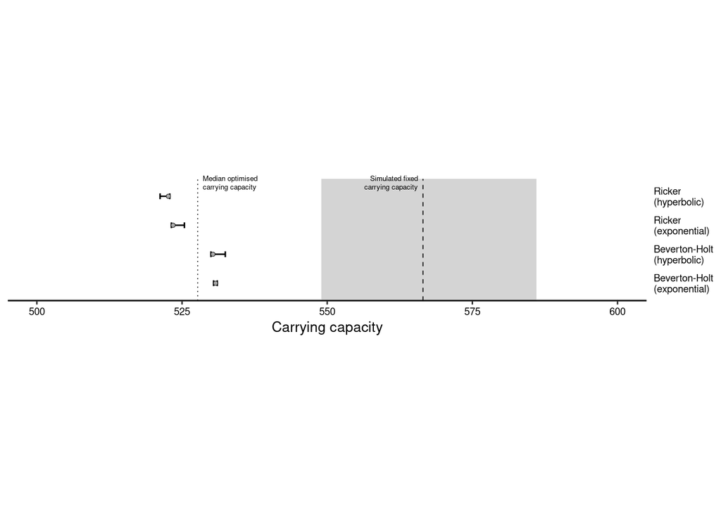

```r
marginalK <- marginalK_df$globalK
minmarginalK <- marginalK_df$lower
maxmarginalK <- marginalK_df$upper

library(ggtext)
# library(ggdist) #Wanted to do with ggdist but there's some error that only occurs on serve
(output <- ggplot() +
  geom_rect(aes(xmin = minmarginalK, xmax = maxmarginalK, ymin = -Inf, ymax = Inf),
            fill = "dark grey", alpha = 0.5) +
  geom_vline(xintercept = marginalK, lty = 2, size = 0.3) +
  geom_vline(xintercept = medianK_allopt, lty = 9, size = 0.3) +
  geom_errorbarh(data = plot_data, aes(y = type, xmin = min, xmax = max), height = 0.2,
                 size = 0.5) +
  geom_point(data = plot_data, aes(y = type, x = mean), shape = 21, size = 1.25, fill = "dark grey",
             stroke = 0.25) +
  geom_richtext(aes(x = marginalK, y = "Ricker_hyp",
                    label = "Simulated fixed<br>carrying capacity"),
                hjust = 1, fill = NA, label.colour = NA,
                vjust = 0, size = 1.75) +
  geom_richtext(aes(x = medianK_allopt, y = "Ricker_hyp",
                    label = "Median optimised<br>carrying capacity"),
                hjust = 0, fill = NA, label.colour = NA,
                vjust = 0, size = 1.75) +
  scale_y_discrete(labels = rev(c("Ricker\n(hyperbolic)",
                                  "Ricker\n(exponential)",
                                  "Beverton-Holt\n(hyperbolic)",
                                  "Beverton-Holt\n(exponential)")),
                   position = "right") +
  scale_x_continuous(breaks = seq(500, 600, 25)) +
  labs(x = "Carrying capacity") +
  coord_fixed(ratio = 5,
              xlim = c(500, 600), clip = "off") +
  theme_classic() +
  theme(axis.line.y = element_blank(),
        axis.text.y = element_markdown(colour = "black", size = 7,
                                       hjust = 0),
        axis.text.x = element_markdown(colour = "black",
                                       size = 7),
        axis.ticks.y = element_blank(),
        axis.title.y = element_blank(),
        axis.title.x = element_markdown(size = 10)))
```

```r
ggsave(output, filename = here::here("analysis/plots/alternative_K_method.png"),
       width = 8.25, height = 3.75, dpi = 600)
```

## PLOT 2: Show estimated values for top models

```r
plot_data2 <- all_fitted_data %>%
  tidyr::unnest(cols = c(x, y))
```

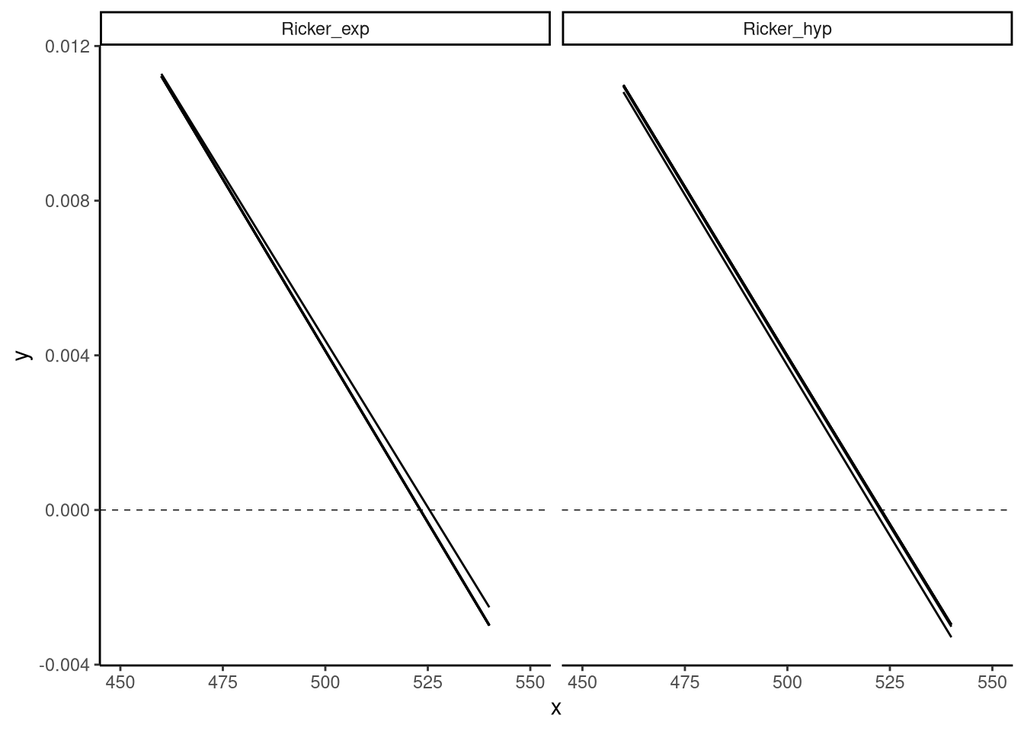

```r
#Ricker models
plot_data_Ricker <- plot_data2 %>%
  filter(grepl(type, pattern = "^Ricker")) %>%
  #Filter data to just around the focal point ~500
  filter(x > 450 & x < 550)

ggplot() +
  geom_hline(yintercept = 0, lty = 2, linewidth = 0.25) +
  geom_line(data = plot_data_Ricker, aes(x = x, y = y, group = opt)) +
  facet_wrap(facets = ~type) +
  coord_cartesian(xlim = c(450, 550)) +
  theme_classic()
```

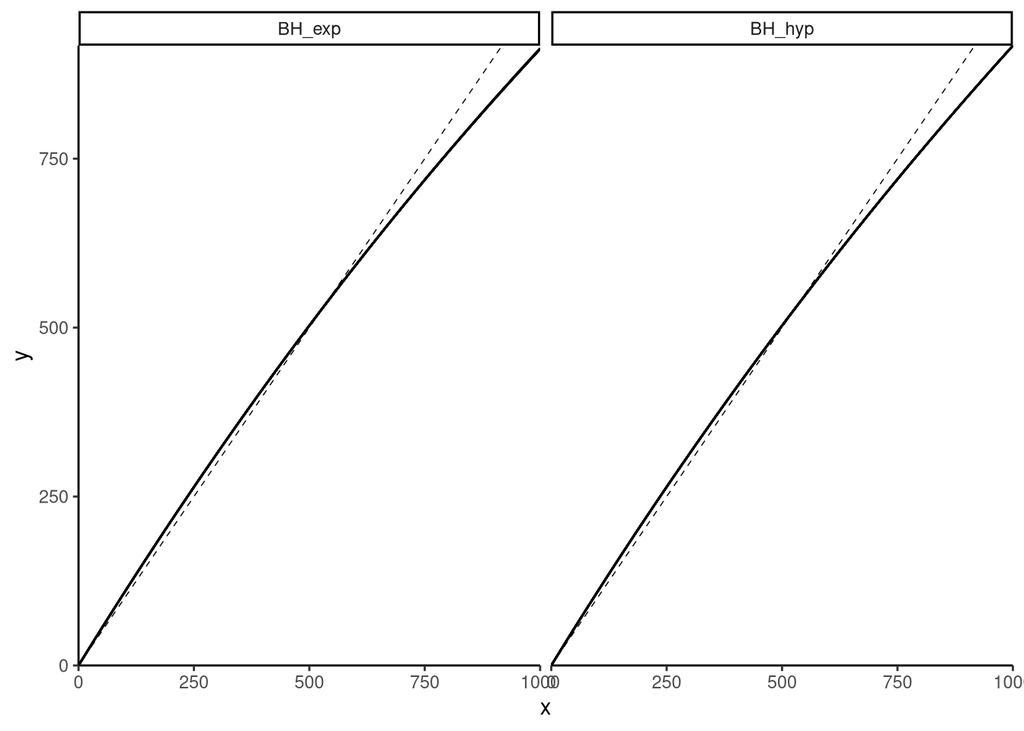

```r
#Beverton-Holt models
plot_data_BH <- plot_data2 %>%
  filter(grepl(type, pattern = "^BH"))

ggplot() +
  geom_abline(slope = 1, intercept = 0, lty = 2, linewidth = 0.25) +
  geom_line(data = plot_data_BH, aes(x = x, y = y, group = opt)) +
  facet_wrap(facets = ~type) +
  coord_cartesian(expand = FALSE) +
  theme_classic()
```